# Dissertation Project: Modelling Universal Basic Income for an AI-Disrupted Labour Market

This notebook is the reproducible workflow accompanying the dissertation. It is organised to mirror the thesis:

1. **Environment Setup** – imports, Drive mount, file paths, helpers.
2. **Data Loading & Validation** – import raw SPSS datasets (+ metadata), quality checks.
3. **Feature Engineering** – derive key household & demographic features.
4. **Simulation** – disposable income under policy scenarios.
5. **Machine Learning** – predictive models on financial vulnerability outcomes.

All intermediate outputs (tables, figures, processed datasets) are saved under `DATA_DIR` for reproducibility.

# Runtime setup – Drive + deps

```python
# 1.1 Mount Google Drive & install deps (Colab)
from google.colab import drive
drive.mount('/content/drive')

# Core reader for SPSS .sav with metadata
!pip -q install pyreadstat
```

# 1 Environment Setup

Prepare the working environment for the dissertation analysis.

- **Library Imports**  
  Load core packages for data analysis (`numpy`, `pandas`), visualisation (`matplotlib`, `seaborn`), file handling, and machine learning (`scikit-learn`).
- **Reproducibility**  
  Set a fixed random seed so any stochastic steps (e.g., train/test split) are repeatable.
- **Directory Paths**  
  Define paths for the project’s data and for outputs (`figures/`, `tables/`, `snapshots/`) so results are saved in a consistent, reproducible structure.
- **Helper Functions**  
  Include small utilities (e.g., a file checker) to fail fast with clear messages if required inputs are missing.

```python
# Core libraries
import numpy as np
import pandas as pd
from pathlib import Path

# File I/O for .sav
import pyreadstat

# Visualisation
import matplotlib.pyplot as plt
import seaborn as sns

# Machine Learning
from sklearn.model_selection import train_test_split
from sklearn.preprocessing import StandardScaler, OneHotEncoder
from sklearn.compose import ColumnTransformer
from sklearn.pipeline import Pipeline
from sklearn.metrics import accuracy_score, confusion_matrix
from sklearn.linear_model import LogisticRegression
from sklearn.ensemble import RandomForestClassifier
from sklearn.model_selection import train_test_split
from sklearn.preprocessing import OneHotEncoder, StandardScaler
from sklearn.compose import ColumnTransformer
from sklearn.pipeline import Pipeline
from sklearn.metrics import (accuracy_score, precision_score, recall_score,
                             f1_score, roc_auc_score, ConfusionMatrixDisplay,
                             RocCurveDisplay)


# ---- Global CONFIG
CONFIG = {
    "DATA_DIR": Path("/content/drive/MyDrive/UBI_Project/data"),
    "FIG_DIR":  Path("/content/drive/MyDrive/UBI_Project/figures"),
    "RANDOM_SEED": 42,
    "FIG_DPI": 150,

      # scenario amounts per month (per adult)
      "SCENARIOS_MONTHLY": {
        "Full_UBI": 500,              # £/month/adult
        "Automation_Dividend": 200,   # £/month/adult
    },

     # GMI rule: top up to 60% of the median *equivalised* income
    "GMI_RULE": {"type": "relative_eq", "poverty_pct": 0.60}
}

# ---- Setup conversions ----
MONTH_TO_WEEK = 12 / 52   # ≈ 0.2308 (conversion from monthly to weekly)

FULL_UBI_PW_ADULT = CONFIG["SCENARIOS_MONTHLY"]["Full_UBI"] * MONTH_TO_WEEK
AUTO_DIVIDEND_PW_ADULT = CONFIG["SCENARIOS_MONTHLY"]["Automation_Dividend"] * MONTH_TO_WEEK


# Reproducibility
np.random.seed(CONFIG["RANDOM_SEED"])

# Ensure output folders exist
CONFIG["DATA_DIR"].mkdir(parents=True, exist_ok=True)
CONFIG["FIG_DIR"].mkdir(parents=True, exist_ok=True)

# Helper: assert a file exists
def check_file(path: Path):
    """Raise error if file not found, otherwise confirm."""
    if not path.exists():
        raise FileNotFoundError(f"❌ File not found: {path}")
    print(f"✅ {path} found")

# Consistent plot style
sns.set_theme(style="whitegrid")         # background + grid
plt.rcParams["figure.figsize"] = (8, 5)  # default figure size

# ---- Visualisation helpers (use CONFIG) ----
def safe_hist(series: pd.Series, title: str, outfile: str):
    """Histogram + KDE for a numeric series; silently skips if no numeric data."""
    s = pd.to_numeric(series, errors="coerce").dropna()
    if s.empty:
        print(f"[skip] {series.name}: no numeric data")
        return
    plt.figure()
    sns.histplot(s, bins=30, kde=True, color="steelblue")
    plt.title(title)
    plt.xlabel(series.name)
    plt.ylabel("Frequency")
    plt.tight_layout()
    plt.savefig(CONFIG["FIG_DIR"] / outfile, dpi=CONFIG["FIG_DPI"], bbox_inches="tight")
    plt.show()
```

# 2 Data Loading & Validation

Load the raw LCFS datasets (household and person files), performs validation checks, and saves defensive snapshots for reproducibility.

Specifically, it:

- Defines file paths for raw `.sav` files and creates organised output folders.
- Loads raw household (DV_HH) and person-level (DVPER) datasets.
- Saves compressed **snapshots** (`.pkl.gz`) to Google Drive for faster reloads in future runs.
- Performs **data quality checks**:
  - Shapes and dimensions of datasets.
  - Duplicate detection.
  - Missingness rates for key variables.
  - Numeric and categorical summaries.
- Produces **diagnostic visuals** (bar plots, histograms, correlation heatmaps) and saves them to the figures folder for inclusion in the appendix.

This ensures all downstream steps (feature engineering, simulations, ML) operate on a validated, well-documented dataset.

```python
# 2.1 Paths, file names, and output folders

# Raw SPSS files
HH_FILE     = CONFIG["DATA_DIR"] / "2014_rawhh_ukanon.sav"
PER_FILE    = CONFIG["DATA_DIR"] / "2014_dvper_ukanon.sav"
HOUSE_FILE  = CONFIG["DATA_DIR"] / "lcfs_households_2014.sav"
RAWPER_FILE = CONFIG["DATA_DIR"] / "2014_rawper_ukanon.sav"

# Output folders for this section
FIG_DIR = CONFIG["FIG_DIR"] / "section2"
TAB_DIR = CONFIG["DATA_DIR"] / "tables" / "section2"
SNAP_DIR = CONFIG["DATA_DIR"] / "snapshots"
for d in [FIG_DIR, TAB_DIR, SNAP_DIR]:
    d.mkdir(parents=True, exist_ok=True)


print("Output dirs ready:", FIG_DIR, TAB_DIR, SNAP_DIR)

# Check existence of inputs (fail fast if missing)
for f in [HH_FILE, PER_FILE, HOUSE_FILE,RAWPER_FILE]:
    check_file(f)
```

```
Output dirs ready: /content/drive/MyDrive/UBI_Project/figures/section2 /content/drive/MyDrive/UBI_Project/data/tables/section2 /content/drive/MyDrive/UBI_Project/data/snapshots
✅ /content/drive/MyDrive/UBI_Project/data/2014_rawhh_ukanon.sav found
✅ /content/drive/MyDrive/UBI_Project/data/2014_dvper_ukanon.sav found
✅ /content/drive/MyDrive/UBI_Project/data/lcfs_households_2014.sav found
✅ /content/drive/MyDrive/UBI_Project/data/2014_rawper_ukanon.sav found
```

```python
# 2.2 Load datasets

# Full paths (for clarity)
hh_path    = HH_FILE
per_path   = PER_FILE
house_path = HOUSE_FILE
rawper_path = RAWPER_FILE

# Snapshot file paths
hh_snap    = SNAP_DIR / "hh_raw.pkl.gz"
per_snap   = SNAP_DIR / "per_raw.pkl.gz"
house_snap = SNAP_DIR / "house_raw.pkl.gz"
rawper_snap = SNAP_DIR/ "rawper_raw.pkl.gz"

# Try to load from snapshots if all exist
if hh_snap.exists() and per_snap.exists() and house_snap.exists() and rawper_snap.exists():
    hh_df    = pd.read_pickle(hh_snap)
    per_df   = pd.read_pickle(per_snap)
    house_df = pd.read_pickle(house_snap)
    rawper_df = pd.read_pickle(rawper_snap)
    print("✅ Loaded household, person & house datasets from snapshots")
else:
    # Otherwise, read raw .sav with metadata (kept here if needed later)
    hh_df,    hh_meta    = pyreadstat.read_sav(str(hh_path))
    per_df,   per_meta   = pyreadstat.read_sav(str(per_path))
    house_df, house_meta = pyreadstat.read_sav(str(house_path))
    rawper_df, rawper_meta = pyreadstat.read_sav(str(rawper_path))

    # Save pristine copies as compressed snapshots
    hh_df.to_pickle(hh_snap, compression="gzip")
    per_df.to_pickle(per_snap, compression="gzip")
    house_df.to_pickle(house_snap, compression="gzip")
    rawper_df.to_pickle(rawper_snap, compression="gzip")
    print("Saved raw snapshots:", hh_snap.name, per_snap.name, house_snap.name, rawper_snap.name)

# Defensive copies so raw stays intact (optional but handy)
hh_raw    = hh_df.copy()
per_raw   = per_df.copy()
house_raw = house_df.copy()
rawper_raw = rawper_df.copy()
```

```
✅ Loaded household, person & house datasets from snapshots
```

```python
# 2.3 Basic Summaries

def _fallback_preview(df, name, n=5):
    print(f"\nPreview: {name}")
    display(df.head(n))
    print("dtypes:")
    display(df.dtypes.head(12))
    print("-" * 80)

# ---- Shapes / quick structure
print("Household dataset shape:", hh_df.shape)
print("Person dataset shape:",    per_df.shape)
print("LCFS dataset shape:",      house_df.shape)
print("RAWPER dataset shape:",     rawper_df.shape)

print("\nHousehold columns (first 12):", hh_df.columns.tolist()[:12], "...")
print("Person columns (first 12):",      per_df.columns.tolist()[:12], "...")
print("LCFS columns (first 12):",        house_df.columns.tolist()[:12], "...")
print("RAWPER columns (first 12):",        rawper_df.columns.tolist()[:12], "...")

# ---- Descriptive stats (numeric + categorical)
hh_desc    = hh_df.describe(include="all").transpose().head(20)
per_desc   = per_df.describe(include="all").transpose().head(20)
house_desc = house_df.describe(include="all").transpose().head(20)
rawper_desc = rawper_df.describe(include="all").transpose().head(20)

# Save and show top rows for readability
hh_desc.to_csv(TAB_DIR / "hh_describe_head20.csv")
per_desc.to_csv(TAB_DIR / "per_describe_head20.csv")
house_desc.to_csv(TAB_DIR / "house_describe_head20.csv")
rawper_desc.to_csv(TAB_DIR / "rawper_describe_head20.csv")

print("\nSaved:",
      (TAB_DIR / "hh_describe_head20.csv").name,
      (TAB_DIR / "per_describe_head20.csv").name,
      (TAB_DIR / "house_describe_head20.csv").name,
      (TAB_DIR / "rawper_describe_head20.csv").name)

display(hh_desc)
display(per_desc)
display(house_desc)
display(rawper_desc)

# ---- Missingness overview (top 20 variables by NA rate)
hh_missing    = hh_df.isna().mean().sort_values(ascending=False).head(20).rename("na_rate").to_frame()
per_missing   = per_df.isna().mean().sort_values(ascending=False).head(20).rename("na_rate").to_frame()
house_missing = house_df.isna().mean().sort_values(ascending=False).head(20).rename("na_rate").to_frame()
rawper_missing = rawper_df.isna().mean().sort_values(ascending=False).head(20).rename("na_rate").to_frame()

hh_missing.to_csv(TAB_DIR / "hh_missing_top20.csv")
per_missing.to_csv(TAB_DIR / "per_missing_top20.csv")
house_missing.to_csv(TAB_DIR / "house_missing_top20.csv")
rawper_missing.to_csv(TAB_DIR / "rawper_missing_top20.csv")

print("\nSaved:",
      (TAB_DIR / "hh_missing_top20.csv").name,
      (TAB_DIR / "per_missing_top20.csv").name,
      (TAB_DIR / "house_missing_top20.csv").name,
      (TAB_DIR / "rawper_missing_top20.csv").name)

display(hh_missing)
display(per_missing)
display(house_missing)
display(rawper_missing)
```

```
Household dataset shape: (5133, 2347)
Person dataset shape: (12111, 308)
LCFS dataset shape: (5133, 1913)
RAWPER dataset shape: (12111, 1421)

Household columns (first 12): ['case', 'Year', 'SampQtr', 'SurvYr', 'GFFMU', 'NimpDry', 'DVHsize', 'DVCsize', 'NumAdult', 'NumChild', 'NumCivPtr', 'NumCPart'] ...
Person columns (first 12): ['case', 'Person', 'A002', 'A003', 'A0031', 'A004', 'A007', 'A010', 'A015', 'A200', 'A201', 'A204'] ...
LCFS columns (first 12): ['case', 'Mscale', 'OECDSc', 'A016', 'A017', 'A018', 'A020', 'A021', 'A022', 'A023', 'A024', 'A025'] ...
RAWPER columns (first 12): ['case', 'Person', 'Hallres2', 'Sex', 'Marchk', 'LivWth12', 'DVMrDF12', 'DVAge4', 'DVAge5', 'DVAge6', 'DVAge9', 'DVAge18'] ...

Saved: hh_describe_head20.csv per_describe_head20.csv house_describe_head20.csv rawper_describe_head20.csv
```

|  | count | unique | top | freq | mean | std | min | 25% | 50% | 75% | max |
| --- | --- | --- | --- | --- | --- | --- | --- | --- | --- | --- | --- |
| case | 5133.0 | NaN | NaN | NaN | 2567.523476 | 1482.345918 | 1.0 | 1284.0 | 2568.0 | 3851.0 | 5134.0 |
| Year | 5133.0 | NaN | NaN | NaN | 2014.0 | 0.0 | 2014.0 | 2014.0 | 2014.0 | 2014.0 | 2014.0 |
| SampQtr | 5133.0 | NaN | NaN | NaN | 2.488993 | 1.118524 | 1.0 | 2.0 | 2.0 | 4.0 | 4.0 |
| SurvYr | 5133.0 | NaN | NaN | NaN | 2014.0 | 0.0 | 2014.0 | 2014.0 | 2014.0 | 2014.0 | 2014.0 |
| GFFMU | 4981.0 | NaN | NaN | NaN | 1.0 | 0.0 | 1.0 | 1.0 | 1.0 | 1.0 | 1.0 |
| NimpDry | 208.0 | NaN | NaN | NaN | 0.865385 | 0.590712 | 0.0 | 0.75 | 1.0 | 1.0 | 2.0 |
| DVHsize | 5133.0 | NaN | NaN | NaN | 2.367621 | 1.251133 | 1.0 | 1.0 | 2.0 | 3.0 | 9.0 |
| DVCsize | 5133.0 | NaN | NaN | NaN | 2.359439 | 1.244617 | 1.0 | 1.0 | 2.0 | 3.0 | 9.0 |
| NumAdult | 5133.0 | NaN | NaN | NaN | 1.903955 | 0.814623 | 1.0 | 1.0 | 2.0 | 2.0 | 8.0 |
| NumChild | 5133.0 | NaN | NaN | NaN | 0.461134 | 0.888295 | 0.0 | 0.0 | 0.0 | 1.0 | 7.0 |
| NumCivPtr | 5133.0 | NaN | NaN | NaN | 0.003507 | 0.083681 | 0.0 | 0.0 | 0.0 | 0.0 | 2.0 |
| NumCPart | 5133.0 | NaN | NaN | NaN | 0.233781 | 0.643854 | 0.0 | 0.0 | 0.0 | 0.0 | 4.0 |
| NumMPart | 5133.0 | NaN | NaN | NaN | 1.009936 | 1.00955 | 0.0 | 0.0 | 2.0 | 2.0 | 4.0 |
| NumHHldr | 5133.0 | NaN | NaN | NaN | 1.544711 | 0.54225 | 1.0 | 1.0 | 2.0 | 2.0 | 6.0 |
| NumCh18 | 5133.0 | NaN | NaN | NaN | 0.546269 | 0.967542 | 0.0 | 0.0 | 0.0 | 1.0 | 7.0 |
| HiHNum | 2720.0 | NaN | NaN | NaN | 1.577941 | 1.905787 | 1.0 | 1.0 | 1.0 | 2.0 | 17.0 |
| JntEldA | 38.0 | NaN | NaN | NaN | 1.473684 | 0.687213 | 1.0 | 1.0 | 1.0 | 2.0 | 4.0 |
| DVHRPNum | 5133.0 | NaN | NaN | NaN | 1.232028 | 0.450308 | 1.0 | 1.0 | 1.0 | 1.0 | 5.0 |
| HRPPart | 5133.0 | NaN | NaN | NaN | 7.570621 | 7.468427 | 1.0 | 2.0 | 2.0 | 17.0 | 17.0 |
| NumDepCh | 5133.0 | NaN | NaN | NaN | 0.542568 | 0.963677 | 0.0 | 0.0 | 0.0 | 1.0 | 7.0 |

|  | count | mean | std | min | 25% | 50% | 75% | max |
| --- | --- | --- | --- | --- | --- | --- | --- | --- |
| case | 12111.0 | 2581.028652 | 1473.867655 | 1.0 | 1310.5 | 2585.0 | 3856.5 | 5134.0 |
| Person | 12111.0 | 2.007927 | 1.157863 | 1.0 | 1.0 | 2.0 | 3.0 | 9.0 |
| A002 | 12111.0 | 1.047560 | 1.405915 | 0.0 | 0.0 | 1.0 | 2.0 | 9.0 |
| A003 | 12111.0 | 1.576170 | 0.494184 | 1.0 | 1.0 | 2.0 | 2.0 | 2.0 |
| A0031 | 12111.0 | 1.739245 | 0.439064 | 1.0 | 1.0 | 2.0 | 2.0 | 2.0 |
| A004 | 12111.0 | 1.516555 | 0.499746 | 1.0 | 1.0 | 2.0 | 2.0 | 2.0 |
| A007 | 12111.0 | 0.979853 | 1.988553 | 0.0 | 0.0 | 0.0 | 0.0 | 9.0 |
| A010 | 12111.0 | 16.295351 | 20.856758 | 0.0 | 0.0 | 16.0 | 18.0 | 97.0 |
| A015 | 12111.0 | 1.345223 | 1.114858 | 0.0 | 1.0 | 1.0 | 2.0 | 4.0 |
| A200 | 12111.0 | 2.567666 | 2.553285 | 0.0 | 1.0 | 1.0 | 6.0 | 8.0 |
| A201 | 12111.0 | 3.597143 | 3.177484 | 0.0 | 0.0 | 4.0 | 7.0 | 7.0 |
| A204 | 12111.0 | 0.001982 | 0.044474 | 0.0 | 0.0 | 0.0 | 0.0 | 1.0 |
| A206 | 12111.0 | 3.139047 | 2.458942 | 0.0 | 1.0 | 2.0 | 6.0 | 7.0 |
| A207 | 12111.0 | 0.132442 | 0.784741 | 0.0 | 0.0 | 0.0 | 0.0 | 6.0 |
| A208 | 12111.0 | 194.158368 | 457.379325 | 0.0 | 0.0 | 0.0 | 86.0 | 3687.0 |
| A2111 | 12111.0 | 0.011147 | 0.104993 | 0.0 | 0.0 | 0.0 | 0.0 | 1.0 |
| A2112 | 12111.0 | 0.000578 | 0.024035 | 0.0 | 0.0 | 0.0 | 0.0 | 1.0 |
| A220 | 12111.0 | 13.334654 | 17.978096 | 0.0 | 0.0 | 0.0 | 35.0 | 97.0 |
| A221 | 12111.0 | 2.106597 | 9.528008 | 0.0 | 0.0 | 0.0 | 0.0 | 97.0 |
| A227 | 12111.0 | 0.002395 | 0.048877 | 0.0 | 0.0 | 0.0 | 0.0 | 1.0 |

|  | count | unique | top | freq | mean | std | min | 25% | 50% | 75% | max |
| --- | --- | --- | --- | --- | --- | --- | --- | --- | --- | --- | --- |
| case | 5133.0 | NaN | NaN | NaN | 2567.523476 | 1482.345918 | 1.0 | 1284.0 | 2568.0 | 3851.0 | 5134.0 |
| Mscale | 5133.0 | NaN | NaN | NaN | 1.059879 | 0.380646 | 0.61 | 0.61 | 1.0 | 1.28 | 3.22 |
| OECDSc | 5133.0 | NaN | NaN | NaN | 1.597467 | 0.514067 | 1.0 | 1.0 | 1.5 | 2.0 | 4.5 |
| A016 | 5133.0 | NaN | NaN | NaN | 0.029223 | 0.17525 | 0.0 | 0.0 | 0.0 | 0.0 | 2.0 |
| A017 | 5133.0 | NaN | NaN | NaN | 0.028638 | 0.170272 | 0.0 | 0.0 | 0.0 | 0.0 | 2.0 |
| A018 | 5133.0 | NaN | NaN | NaN | 0.057861 | 0.246493 | 0.0 | 0.0 | 0.0 | 0.0 | 2.0 |
| A020 | 5133.0 | NaN | NaN | NaN | 0.030586 | 0.173339 | 0.0 | 0.0 | 0.0 | 0.0 | 2.0 |
| A021 | 5133.0 | NaN | NaN | NaN | 0.050847 | 0.2343 | 0.0 | 0.0 | 0.0 | 0.0 | 2.0 |
| A022 | 5133.0 | NaN | NaN | NaN | 0.185856 | 0.49642 | 0.0 | 0.0 | 0.0 | 0.0 | 4.0 |
| A023 | 5133.0 | NaN | NaN | NaN | 0.344243 | 0.546854 | 0.0 | 0.0 | 0.0 | 1.0 | 5.0 |
| A024 | 5133.0 | NaN | NaN | NaN | 0.238067 | 0.43004 | 0.0 | 0.0 | 0.0 | 0.0 | 2.0 |
| A025 | 5133.0 | NaN | NaN | NaN | 0.070329 | 0.255726 | 0.0 | 0.0 | 0.0 | 0.0 | 1.0 |
| A026 | 5133.0 | NaN | NaN | NaN | 0.079291 | 0.270219 | 0.0 | 0.0 | 0.0 | 0.0 | 1.0 |
| A027 | 5133.0 | NaN | NaN | NaN | 0.141438 | 0.349065 | 0.0 | 0.0 | 0.0 | 0.0 | 2.0 |
| A030 | 5133.0 | NaN | NaN | NaN | 0.030976 | 0.178804 | 0.0 | 0.0 | 0.0 | 0.0 | 2.0 |
| A031 | 5133.0 | NaN | NaN | NaN | 0.042665 | 0.213376 | 0.0 | 0.0 | 0.0 | 0.0 | 3.0 |
| A032 | 5133.0 | NaN | NaN | NaN | 0.179232 | 0.500021 | 0.0 | 0.0 | 0.0 | 0.0 | 4.0 |
| A033 | 5133.0 | NaN | NaN | NaN | 0.389441 | 0.559846 | 0.0 | 0.0 | 0.0 | 1.0 | 6.0 |
| A034 | 5133.0 | NaN | NaN | NaN | 0.250731 | 0.436611 | 0.0 | 0.0 | 0.0 | 0.0 | 2.0 |
| A035 | 5133.0 | NaN | NaN | NaN | 0.084356 | 0.277948 | 0.0 | 0.0 | 0.0 | 0.0 | 1.0 |

|  | count | unique | top | freq | mean | std | min | 25% | 50% | 75% | max |
| --- | --- | --- | --- | --- | --- | --- | --- | --- | --- | --- | --- |
| case | 12111.0 | NaN | NaN | NaN | 2581.028652 | 1473.867655 | 1.0 | 1310.5 | 2585.0 | 3856.5 | 5134.0 |
| Person | 12111.0 | NaN | NaN | NaN | 2.007927 | 1.157863 | 1.0 | 1.0 | 2.0 | 3.0 | 9.0 |
| Hallres2 | 12111.0 | NaN | NaN | NaN | 2.0 | 0.0 | 2.0 | 2.0 | 2.0 | 2.0 | 2.0 |
| Sex | 12111.0 | NaN | NaN | NaN | 1.516555 | 0.499746 | 1.0 | 1.0 | 2.0 | 2.0 | 2.0 |
| Marchk | 5202.0 | NaN | NaN | NaN | 1.000384 | 0.019606 | 1.0 | 1.0 | 1.0 | 1.0 | 2.0 |
| LivWth12 | 3192.0 | NaN | NaN | NaN | 1.62406 | 0.484441 | 1.0 | 1.0 | 2.0 | 2.0 | 2.0 |
| DVMrDF12 | 12111.0 | NaN | NaN | NaN | 2.241103 | 1.283638 | 1.0 | 1.0 | 2.0 | 3.0 | 8.0 |
| DVAge4 | 12111.0 | NaN | NaN | NaN | 1.987367 | 0.850174 | 1.0 | 1.0 | 2.0 | 2.0 | 4.0 |
| DVAge5 | 12111.0 | NaN | NaN | NaN | 2.807283 | 1.231777 | 1.0 | 2.0 | 3.0 | 4.0 | 5.0 |
| DVAge6 | 12111.0 | NaN | NaN | NaN | 3.260012 | 1.504308 | 1.0 | 2.0 | 3.0 | 4.0 | 6.0 |
| DVAge9 | 12111.0 | NaN | NaN | NaN | 4.199818 | 2.309719 | 1.0 | 2.0 | 4.0 | 6.0 | 9.0 |
| DVAge18 | 12111.0 | NaN | NaN | NaN | 8.779704 | 4.763405 | 1.0 | 5.0 | 9.0 | 13.0 | 18.0 |
| WorkAge | 12111.0 | NaN | NaN | NaN | 2.035587 | 0.652864 | 1.0 | 2.0 | 2.0 | 2.0 | 3.0 |
| JDate | 12111.0 | NaN | NaN | NaN | 720252.145322 | 8661.356213 | 699041.0 | 713132.5 | 719776.0 | 727662.5 | 735542.0 |
| Restme2 | 12111.0 | NaN | NaN | NaN | 12.498307 | 12.832432 | 0.0 | 3.0 | 8.0 | 18.0 | 89.0 |
| ResMth | 1179.0 | NaN | NaN | NaN | 5.08821 | 2.940385 | 1.0 | 3.0 | 5.0 | 7.0 | 11.0 |
| QHealth1 | 9738.0 | NaN | NaN | NaN | 1.960978 | 0.925663 | 1.0 | 1.0 | 2.0 | 2.0 | 5.0 |
| HealIll | 9738.0 | NaN | NaN | NaN | 1.602588 | 0.489388 | 1.0 | 1.0 | 2.0 | 2.0 | 2.0 |
| RedAct | 3870.0 | NaN | NaN | NaN | 2.030233 | 0.787185 | 1.0 | 1.0 | 2.0 | 3.0 | 3.0 |
| Durredact | 2611.0 | NaN | NaN | NaN | 2.881272 | 0.413931 | 1.0 | 3.0 | 3.0 | 3.0 | 3.0 |

```
Saved: hh_missing_top20.csv per_missing_top20.csv house_missing_top20.csv rawper_missing_top20.csv
```

|  | na_rate |
| --- | --- |
| PaidFor4 | 1.000000 |
| AdvAmt4 | 1.000000 |
| MeaPer4 | 1.000000 |
| NewO10 | 1.000000 |
| DVAdv4 | 1.000000 |
| DVOthTot | 0.999805 |
| OthTot | 0.999805 |
| Ed1Psn6 | 0.999805 |
| DVSTRI3 | 0.999805 |
| StrIPrc3 | 0.999805 |
| HolIamt3 | 0.999805 |
| O_StrIPrem3 | 0.999805 |
| StrIType3 | 0.999805 |
| HInPsn3 | 0.999805 |
| StrIVal2 | 0.999805 |
| InsAny3 | 0.999805 |
| O_TVTot2 | 0.999805 |
| O_MobTot2 | 0.999805 |
| ComAny3 | 0.999805 |
| DVMobTot3 | 0.999805 |

|  | na_rate |
| --- | --- |
| a013p | 0.739245 |
| a012p | 0.576170 |
| A2261 | 0.000000 |
| P153c | 0.000000 |
| P136c | 0.000000 |
| P135c | 0.000000 |
| P134c | 0.000000 |
| P133c | 0.000000 |
| P132c | 0.000000 |
| A2262 | 0.000000 |
| P130c | 0.000000 |
| P129c | 0.000000 |
| P128c | 0.000000 |
| P126c | 0.000000 |
| P121c | 0.000000 |
| P120c | 0.000000 |
| P119c | 0.000000 |
| P118c | 0.000000 |
| P117c | 0.000000 |
| P153 | 0.000000 |

|  | na_rate |
| --- | --- |
| p396p | 0.0 |
| case | 0.0 |
| Mscale | 0.0 |
| OECDSc | 0.0 |
| A016 | 0.0 |
| A017 | 0.0 |
| A018 | 0.0 |
| A020 | 0.0 |
| A021 | 0.0 |
| P320p | 0.0 |
| EqIncDOp | 0.0 |
| EqIncDMp | 0.0 |
| P356p | 0.0 |
| P352p | 0.0 |
| P389p | 0.0 |
| P073hp | 0.0 |
| P029hp | 0.0 |
| P388p | 0.0 |
| P392p | 0.0 |
| B391hp | 0.0 |

|  | na_rate |
| --- | --- |
| DVSeTax3p | 1.0 |
| DVTaxD3p | 1.0 |
| SeTaxAmt3p | 1.0 |
| BenAmtDK34 | 1.0 |
| BenAmtDK35 | 1.0 |
| BenAmtDK36 | 1.0 |
| R11 | 1.0 |
| R12 | 1.0 |
| R13 | 1.0 |
| R14 | 1.0 |
| R15 | 1.0 |
| R16 | 1.0 |
| Rinverse09 | 1.0 |
| Rinverse10 | 1.0 |
| BenAmtDK32 | 1.0 |
| BenAmtDK33 | 1.0 |
| Weeks58 | 1.0 |
| BenLettr30 | 1.0 |
| BankStmt30 | 1.0 |
| BenAmt30 | 1.0 |

```python
# 2.4 Validation & Auto-detect key variables (works with hh_df, per_df, house_df, rawper_df)

import numpy as np
import pandas as pd
from pathlib import Path

# ---------- helpers ----------
def pick_col(df, candidates):
    """Return the first candidate that exists in df.columns (case-insensitive safe)."""
    if df is None:
        return None
    cols_lower = {c.lower(): c for c in df.columns}
    for c in candidates:
        if c is None:
            continue
        if c.lower() in cols_lower:
            return cols_lower[c.lower()]
    return None

def save_value_counts(df, col, out_path, top=30):
    try:
        vc = df[col].value_counts(dropna=False).head(top)
        vc.to_frame("count").to_csv(out_path)
    except Exception as e:
        print(f"[warn] could not save value counts for {col}: {e}")

# ---------- candidate lists (robust to naming variants) ----------
# Keys
CASE_CAND_HH   = ["case", "Case", "CASE", "Case Number", "CASEID", "CaseID"]
CASE_CAND_PER  = CASE_CAND_HH
PERSON_CAND    = ["Person", "PERSON", "person", "PERSNO", "Person number"]

# HRP & basic demo (from DVPER)
HRP_FLAG_CAND  = ["A003", "a003"]                     # HRP flag
AGE_CAND       = ["A005p", "A005", "a005p", "Age - anonymised", "Age (anonymised)"]
SEX_CAND       = ["A004", "a004", "gender", "Gender", "Sex"]

# Employment (FES/ES2000)
EMP_CAND       = ["A206"]

# Education (highest)
EDUC_CAND      = ["HighEd1", "Highed1", "a019", "A019", "Highest qualification", "DVHIQUL"]

# Ethnicity (HRP / grouped)
ETH_CAND       = ["A012p", "a012p", "A013p", "a013p", "Ethnic origin - anonymised", "Ethnic origin - grouped"]

# Marital / partnership status
MAR_CAND       = ["A006p", "a006p", "Xmarsta_p", "a006", "Marital status - anonymised"]

# Household composition (RAW_HH)
HHSIZE_CAND    = ["DVHsize", "DVHSize", "hhsize", "HHsize", "Household size", "HhSize"]
NUMADULT_CAND  = ["NumAdult", "numadult", "Number of adults"]
NUMCHILD_CAND  = ["NumChild", "numchild", "Number of children", "NumCh18"]  # we’ll prefer NumChild; NumCh18 is fallback

# LCFS (households) income & scales/region/tenure
DISP_INC_CAND  = ["P389p", "p389p", "EqIncDOp", "EqIncDMp"]  # prefer P389p
EQ_SCALE_CAND  = ["OECDSc", "oecdsc", "Mscale", "mscale"]
REGION_CAND    = ["Gorx", "GORX", "Region", "GOR"]
TENURE_CAND    = ["A122", "a122", "Ten1", "ten1", "Tenure harmonised", "Accom"]

# Lone parent (often derived or survey item in rawper/hh; we try common labels)
LONEP_CAND     = ["SingPar", "singpar", "Is a single parent", "lone_parent"]

# ---------- locate columns in each dataframe ----------
CASE_COL_HH   = pick_col(hh_df,   CASE_CAND_HH)
CASE_COL_PER  = pick_col(per_df,  CASE_CAND_PER)
CASE_COL_HOUSE= pick_col(house_df,CASE_CAND_HH)
PERSON_COL    = pick_col(per_df,  PERSON_CAND)

HRP_FLAG = pick_col(per_df,  HRP_FLAG_CAND)
AGE_COL  = pick_col(per_df,  AGE_CAND)
SEX_COL  = pick_col(per_df,  SEX_CAND)
EMP_COL  = pick_col(per_df,  EMP_CAND)
EDUC_COL = pick_col(per_df,  EDUC_CAND) or pick_col(rawper_df, EDUC_CAND)
ETH_COL  = pick_col(per_df,  ETH_CAND)
MAR_COL  = pick_col(per_df,  MAR_CAND)

HHSIZE   = pick_col(hh_df,   HHSIZE_CAND)
NUM_ADULT= pick_col(hh_df,   NUMADULT_CAND)
NUM_CHILD= pick_col(hh_df,   NUMCHILD_CAND)

DISP_INC = pick_col(house_df, DISP_INC_CAND)
EQ_SCALE = pick_col(house_df, EQ_SCALE_CAND)
REGION_COL = pick_col(house_df, REGION_CAND)
TENURE_COL = pick_col(house_df, TENURE_CAND)

# Try lone-parent in any file, prioritising rawper then hh, then per
LONEP_COL = pick_col(rawper_df, LONEP_CAND) or pick_col(hh_df, LONEP_CAND) or pick_col(per_df, LONEP_CAND)


# ---------- report what we found ----------
found = {
    "KEYS": {
        "CASE_COL_HH": CASE_COL_HH, "CASE_COL_PER": CASE_COL_PER,
        "CASE_COL_HOUSE": CASE_COL_HOUSE, "PERSON_COL": PERSON_COL
    },
    "DVPER": {
        "HRP_FLAG": HRP_FLAG, "AGE_COL": AGE_COL, "SEX_COL": SEX_COL,
        "EMP_COL": EMP_COL, "EDUC_COL": EDUC_COL, "ETH_COL": ETH_COL, "MAR_COL": MAR_COL
    },
    "RAW_HH": {
        "HHSIZE": HHSIZE, "NUM_ADULT": NUM_ADULT, "NUM_CHILD": NUM_CHILD
    },
    "LCFS_HOUSE": {
        "DISP_INC": DISP_INC, "EQ_SCALE": EQ_SCALE, "REGION": REGION_COL, "TENURE": TENURE_COL
    },
    "OTHER": {
        "LONE_PARENT": LONEP_COL
    }
}

print("=== Auto-detected columns ===")
for grp, items in found.items():
    print(f"\n[{grp}]")
    for k, v in items.items():
        print(f"  {k:12s} -> {v}")

# ---------- persist a small audit (optional, skip if TAB_DIR not set) ----------
try:
    audit_dir = TAB_DIR / "section2"
    audit_dir.mkdir(parents=True, exist_ok=True)
    pd.Series({(g+"."+k): v for g, d in found.items() for k, v in d.items()}).to_csv(audit_dir / "variable_detection_summary.csv")
    # save value_counts for quick look
    vc_dir = audit_dir / "value_counts"
    vc_dir.mkdir(exist_ok=True)
    for df, cols, tag in [
        (per_df,  [c for c in [HRP_FLAG, AGE_COL, SEX_COL, EMP_COL, EDUC_COL, ETH_COL, MAR_COL] if c], "per"),
        (hh_df,   [c for c in [HHSIZE, NUM_ADULT, NUM_CHILD] if c], "hh"),
        (house_df,[c for c in [DISP_INC, EQ_SCALE, REGION_COL, TENURE_COL] if c], "lcfs"),
        (rawper_df,[c for c in [LONEP_COL] if c], "rawper")
    ]:
        for c in cols:
            save_value_counts(df, c, vc_dir / f"{tag}_{c}_vc.csv", top=40)
    print(f"\nSaved detection audit to {audit_dir}")
except Exception as e:
    print(f"[note] Skip saving audit (TAB_DIR may not exist here): {e}")

# ---------- build VARIABLE_PLAN (to be used in Section 3 merge) ----------
VARIABLE_PLAN = {
    "keys":   {"case": CASE_COL_HH, "person": PERSON_COL},
    "hrp":    {"flag": HRP_FLAG, "age": AGE_COL},
    "comp":   {"hhsize": HHSIZE, "n_adult": NUM_ADULT, "n_child": NUM_CHILD},
    "income": {"weekly_disp_hh": DISP_INC},
    "demo":   {
        "sex":   SEX_COL,
        "emp":   EMP_COL,
        "eth":   ETH_COL,
        "mar":   MAR_COL,
        "tenure":TENURE_COL,
        "educ":  EDUC_COL,
        "region":REGION_COL,
        "lone_parent": LONEP_COL,
        "eq_scale": EQ_SCALE,
    }
}

print("\nVARIABLE_PLAN:")
print(VARIABLE_PLAN)
```

```
=== Auto-detected columns ===

[KEYS]
  CASE_COL_HH  -> case
  CASE_COL_PER -> case
  CASE_COL_HOUSE -> case
  PERSON_COL   -> Person

[DVPER]
  HRP_FLAG     -> A003
  AGE_COL      -> a005p
  SEX_COL      -> A004
  EMP_COL      -> A206
  EDUC_COL     -> HighEd1
  ETH_COL      -> a012p
  MAR_COL      -> a006p

[RAW_HH]
  HHSIZE       -> DVHsize
  NUM_ADULT    -> NumAdult
  NUM_CHILD    -> NumChild

[LCFS_HOUSE]
  DISP_INC     -> P389p
  EQ_SCALE     -> OECDSc
  REGION       -> Gorx
  TENURE       -> A122

[OTHER]
  LONE_PARENT  -> SingPar
[warn] could not save value counts for HighEd1: 'HighEd1'

Saved detection audit to /content/drive/MyDrive/UBI_Project/data/tables/section2/section2

VARIABLE_PLAN:
{'keys': {'case': 'case', 'person': 'Person'}, 'hrp': {'flag': 'A003', 'age': 'a005p'}, 'comp': {'hhsize': 'DVHsize', 'n_adult': 'NumAdult', 'n_child': 'NumChild'}, 'income': {'weekly_disp_hh': 'P389p'}, 'demo': {'sex': 'A004', 'emp': 'A206', 'eth': 'a012p', 'mar': 'a006p', 'tenure': 'A122', 'educ':…
```

```python
# ===== Duplicate-key checks=====

# Also detect case+person for RAW_PER so we can check (case, person)
CASE_COL_RAWPER  = pick_col(rawper_df, CASE_CAND_HH)
RPER_PERSON_COL  = pick_col(rawper_df, PERSON_CAND)

dup_rows = []

def add_dup(df, name, subset):
    if df is None or any(c is None for c in subset):
        dup_rows.append({"dataset": name, "key": str(subset), "dup_rows": "n/a"})
        return
    n_dups = int(df.duplicated(subset=subset).sum())
    dup_rows.append({"dataset": name, "key": str(subset), "dup_rows": n_dups})

# One-column case keys
add_dup(hh_df,     "RAW_HH",        [CASE_COL_HH])
add_dup(house_df,  "LCFS_HOUSE",    [CASE_COL_HOUSE])

# Two-column (case, person) keys
add_dup(per_df,    "DVPER",         [CASE_COL_PER, PERSON_COL])
add_dup(rawper_df, "RAW_PER",       [CASE_COL_RAWPER, RPER_PERSON_COL])

dup_report = pd.DataFrame(dup_rows)
print("\nDuplicate-key summary:")
display(dup_report)

# Save to tables/section2 if available
try:
    out_dir = TAB_DIR / "section2"
    out_dir.mkdir(parents=True, exist_ok=True)
    dup_report.to_csv(out_dir / "duplicate_keys_report.csv", index=False)
    print(f"Saved duplicate report -> {out_dir/'duplicate_keys_report.csv'}")
except Exception as e:
    print(f"[note] Could not save duplicate report: {e}")
```

```
Duplicate-key summary:
```

|  | dataset | key | dup_rows |
| --- | --- | --- | --- |
| 0 | RAW_HH | ['case'] | 0 |
| 1 | LCFS_HOUSE | ['case'] | 0 |
| 2 | DVPER | ['case', 'Person'] | 0 |
| 3 | RAW_PER | ['case', 'Person'] | 0 |

```
Saved duplicate report -> /content/drive/MyDrive/UBI_Project/data/tables/section2/section2/duplicate_keys_report.csv
```

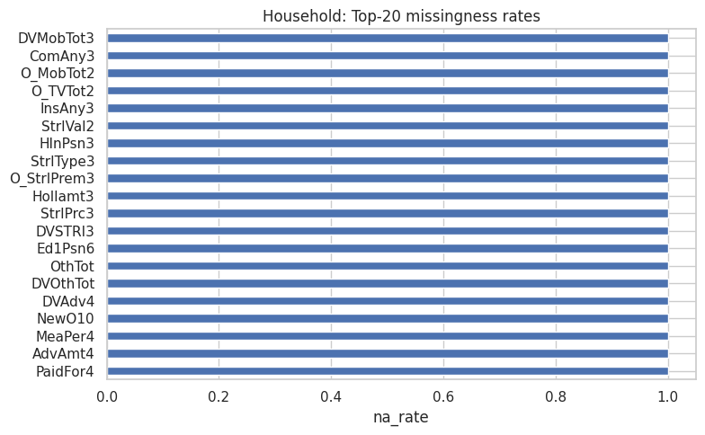

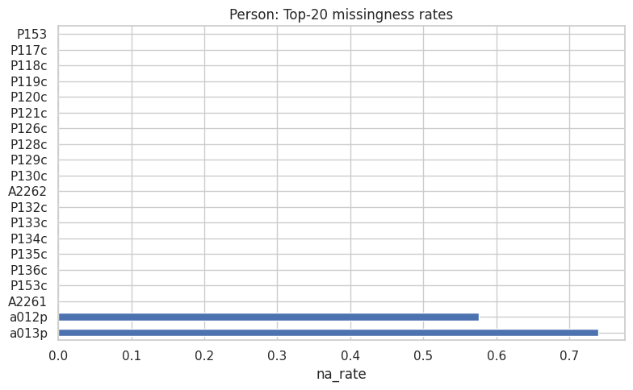

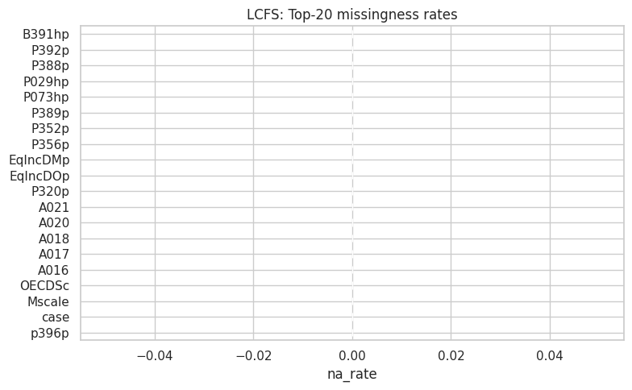

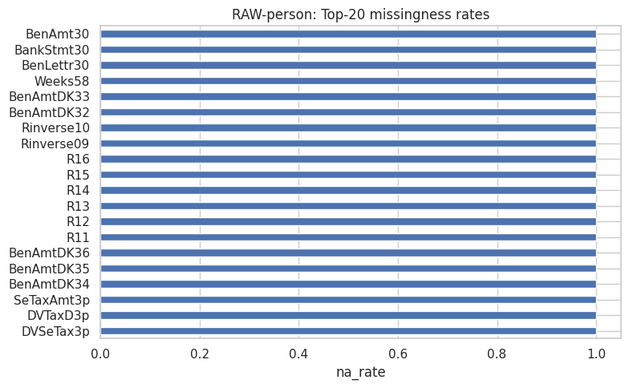

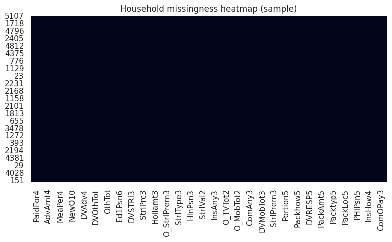

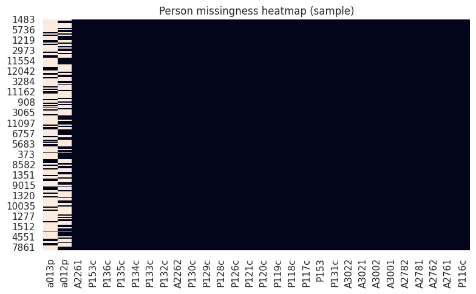

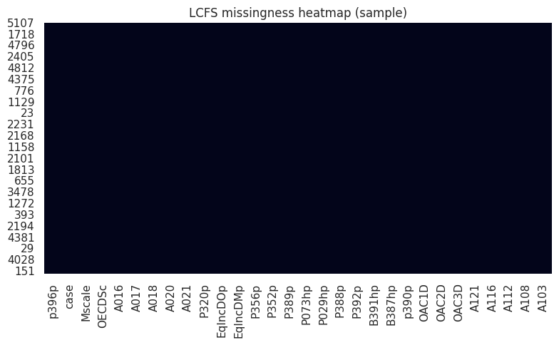

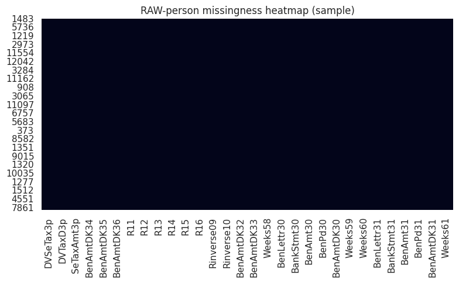

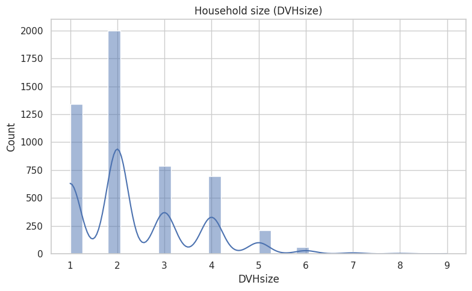

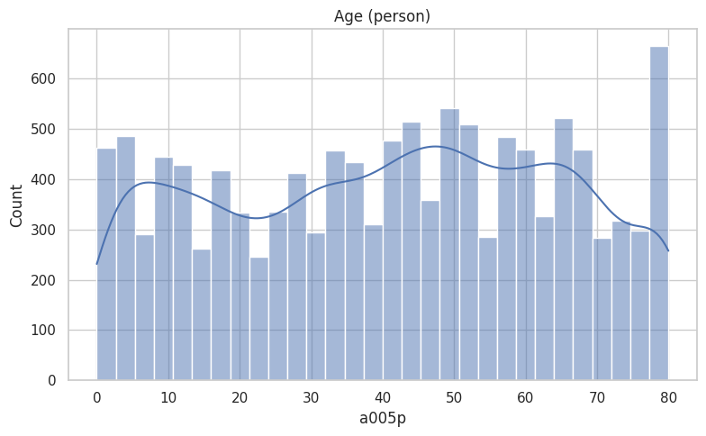

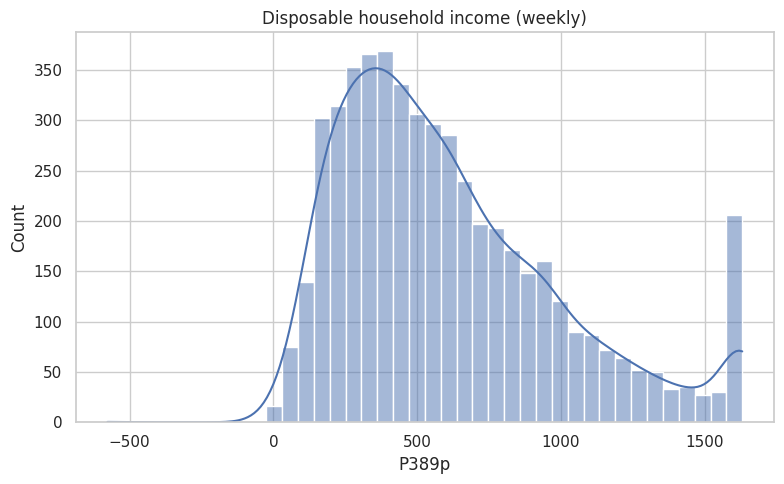

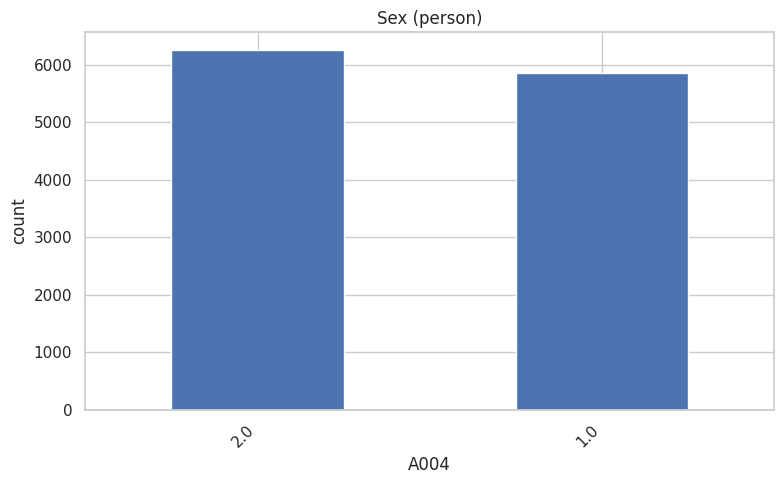

[7 more figures not shown]

```python
# 2.5 Raw Data Plots (raw exploration) — cleaned & synced with 2.4

import numpy as np
import pandas as pd
import matplotlib.pyplot as plt
import seaborn as sns
from pathlib import Path

# ----------------- figure setup -----------------
FIG_DIR = Path(CONFIG["FIG_DIR"]) / "section2"
FIG_DIR.mkdir(parents=True, exist_ok=True)
FIG_DPI = CONFIG.get("FIG_DPI", 150)

# ----------------- helpers -----------------
def bar_counts(series, title, outfile, topn=None):
    if series is None:
        print(f"[skip] {title}: no series")
        return
    vc = series.value_counts(dropna=False)
    if topn is not None:
        vc = vc.head(topn)
    plt.figure()
    vc.sort_values(ascending=False).plot(kind="bar")
    plt.title(title)
    plt.xlabel(series.name)
    plt.ylabel("count")
    plt.xticks(rotation=45, ha="right")
    plt.tight_layout()
    plt.savefig(FIG_DIR / outfile, dpi=FIG_DPI, bbox_inches="tight")
    plt.show()

def corr_heatmap(df_subset, title, outfile):
    # numeric-only, drop rows with any NA across chosen columns
    num = df_subset.select_dtypes(include=np.number).dropna()
    if num.shape[1] < 2 or num.shape[0] < 2:
        print("[skip] not enough numeric data for correlation heatmap")
        return
    C = num.corr(method="pearson")
    plt.figure()
    sns.heatmap(C, annot=False, cmap="vlag", center=0)
    plt.title(title)
    plt.tight_layout()
    plt.savefig(FIG_DIR / outfile, dpi=FIG_DPI, bbox_inches="tight")
    plt.show()

def missing_bar(df, title, outfile):
    s = df.isna().mean().sort_values(ascending=False).head(20).rename("na_rate")
    plt.figure()
    s.plot(kind="barh")
    plt.title(title)
    plt.xlabel("na_rate")
    plt.tight_layout()
    plt.savefig(FIG_DIR / outfile, dpi=FIG_DPI, bbox_inches="tight")
    plt.show()

def missing_heatmap(df, title, outfile, n_rows=200, n_cols=30):
    # purely illustrative: small patch of the data to show 'patchiness'
    if df.shape[1] == 0:
        print("[skip] empty df for missing heatmap")
        return
    cols = df.isna().mean().sort_values(ascending=False).head(n_cols).index
    if len(cols) == 0:
        print("[skip] no missingness to plot")
        return
    n = min(n_rows, len(df))
    samp = df.sample(n=n, random_state=42)
    plt.figure()
    sns.heatmap(samp[cols].isna(), cbar=False)
    plt.title(title)
    plt.tight_layout()
    plt.savefig(FIG_DIR / outfile, dpi=FIG_DPI, bbox_inches="tight")
    plt.show()

def pick_first(df, candidates):
    if df is None:
        return None
    for c in candidates:
        if c in df.columns:
            return c
        # case-insensitive tolerance
        for col in df.columns:
            if str(col).lower() == str(c).lower():
                return col
    return None

# ----------------- candidate lookups (match 2.4) -----------------
HHSIZE_COL  = pick_first(hh_df,   ["DVHsize","DVHSize","hhsize","HHsize","Household size","HhSize"])
AGE_COL     = pick_first(per_df,  ["A005p","A005","Age - anonymised","Age (anonymised)"])
SEX_COL     = pick_first(per_df,  ["A004","gender","Gender","Sex"])
EMP_COL     = pick_first(per_df,  ["A206","A208","DVILO3a","DVILO4a"])
INCOME_COL  = pick_first(house_df,["P389p","EqIncDOp","EqIncDMp"])   # LCFS weekly disposable income (prefer P389p)

# extra demos from per_df (optional if present)
PER_MAR_COL  = pick_first(per_df,  ["A006p","Xmarsta_p","mar","marital","DVMRDF"])
PER_EDU_COL  = pick_first(rawper_df,  ["HighEd1","A019","Highed1","educ","qualification","DVHIQUL"])
PER_ETH_COL  = pick_first(per_df,  ["A012p","A013p","eth","ethnicity"])

# ----------------- 1) Missingness bars -----------------
if 'hh_df' in globals():
    missing_bar(hh_df,  "Household: Top-20 missingness rates",  "hh_missing_top20_bar.png")
if 'per_df' in globals():
    missing_bar(per_df, "Person: Top-20 missingness rates",     "per_missing_top20_bar.png")
if 'house_df' in globals():
    missing_bar(house_df,"LCFS: Top-20 missingness rates",      "house_missing_top20_bar.png")
if 'rawper_df' in globals():
    missing_bar(rawper_df,"RAW-person: Top-20 missingness rates","rawper_missing_top20_bar.png")

# ----------------- 2) Patchiness heatmaps (small samples) -----------------
if 'hh_df' in globals():
    missing_heatmap(hh_df,  "Household missingness heatmap (sample)", "hh_missing_heatmap.png")
if 'per_df' in globals():
    missing_heatmap(per_df, "Person missingness heatmap (sample)",    "per_missing_heatmap.png")
if 'house_df' in globals():
    missing_heatmap(house_df,"LCFS missingness heatmap (sample)",     "house_missing_heatmap.png")
if 'rawper_df' in globals():
    missing_heatmap(rawper_df,"RAW-person missingness heatmap (sample)","rawper_missing_heatmap.png")

# ----------------- 3) Histograms: key numeric vars -----------------
if HHSIZE_COL and HHSIZE_COL in hh_df.columns:
    s = pd.to_numeric(hh_df[HHSIZE_COL], errors="coerce").dropna()
    plt.figure()
    sns.histplot(s, bins=30, kde=True)
    plt.title("Household size (DVHsize)")
    plt.xlabel(HHSIZE_COL)
    plt.tight_layout()
    plt.savefig(FIG_DIR / "hist_hh_size.png", dpi=FIG_DPI, bbox_inches="tight")
    plt.show()
else:
    print("[skip] Household size column not found")

if AGE_COL and AGE_COL in per_df.columns:
    s = pd.to_numeric(per_df[AGE_COL], errors="coerce").dropna()
    plt.figure()
    sns.histplot(s, bins=30, kde=True)
    plt.title("Age (person)")
    plt.xlabel(AGE_COL)
    plt.tight_layout()
    plt.savefig(FIG_DIR / "hist_age.png", dpi=FIG_DPI, bbox_inches="tight")
    plt.show()
else:
    print("[skip] Age column not found")

if INCOME_COL and INCOME_COL in house_df.columns:
    s = pd.to_numeric(house_df[INCOME_COL], errors="coerce").dropna()
    plt.figure()
    sns.histplot(s, bins=40, kde=True)
    plt.title("Disposable household income (weekly)")
    plt.xlabel(INCOME_COL)
    plt.tight_layout()
    plt.savefig(FIG_DIR / "hist_disposable_income.png", dpi=FIG_DPI, bbox_inches="tight")
    plt.show()
else:
    print("[skip] Disposable income column not found in LCFS/house_df")

# ----------------- 4) Categorical examples (person-level) -----------------
if SEX_COL and SEX_COL in per_df.columns:
    bar_counts(per_df[SEX_COL], "Sex (person)", "bar_sex.png")
else:
    print("[skip] Sex column not found")

if EMP_COL and EMP_COL in per_df.columns:
    bar_counts(per_df[EMP_COL], "Employment status (A206)", "bar_employment.png")
else:
    print("[skip] Employment column not found")

# Optional: extra categorical bars from per_df (if present)
for col, title, fn in [
    (PER_MAR_COL, "Marital / partnership status", "per_bar_marital.png"),
    (PER_EDU_COL, "Highest qualification / education", "per_bar_education.png"),
    (PER_ETH_COL, "Ethnic origin (anonymised / grouped)", "per_bar_ethnicity.png"),
]:
    if col and col in per_df.columns:
        bar_counts(per_df[col], title, fn)

# ----------------- 5) NEW: Categorical examples from rawper_df (if present) -----------------
if 'rawper_df' in globals():
    RAW_MAR_COL = pick_first(rawper_df, ["A006p","Xmarsta_p","mar","marital","DVMRDF"])
    RAW_EDU_COL = pick_first(rawper_df, ["HighEd1","A019","Highed1","educ","qualification"])
    RAW_ETH_COL = pick_first(rawper_df, ["A012p","A013p","eth","ethnicity"])
    RAW_LP_COL  = pick_first(rawper_df, ["SingPar","singpar","Is a single parent","lone_parent"])

    if RAW_MAR_COL: bar_counts(rawper_df[RAW_MAR_COL], "Marital / partnership status (rawper)", "bar_marital_rawper.png")
    else:           print("[skip] Marital status column not found in rawper_df")

    if RAW_EDU_COL: bar_counts(rawper_df[RAW_EDU_COL], "Highest qualification / education (rawper)", "bar_education_rawper.png")
    else:           print("[skip] Education column not found in rawper_df")

    if RAW_ETH_COL: bar_counts(rawper_df[RAW_ETH_COL], "Ethnic origin (rawper)", "bar_ethnicity_rawper.png")
    else:           print("[skip] Ethnicity column not found in rawper_df")

    if RAW_LP_COL:  bar_counts(rawper_df[RAW_LP_COL], "Lone parent indicator (rawper)", "bar_lone_parent_rawper.png")
    else:           print("[skip] Lone-parent column not found in rawper_df")

# ----------------- 6) Correlation heatmap (selected numeric subset) -----------------
# Build from household numerics and bring LCFS income onto the same rows by case
num_candidates_hh = [c for c in ["DVHsize","NumAdult","NumChild","DVnumBU","OECDSc","Mscale"] if c in hh_df.columns]

if INCOME_COL and INCOME_COL in house_df.columns and "case" in hh_df.columns and "case" in house_df.columns:
    income_by_case = house_df.set_index("case")[INCOME_COL]
    tmp = hh_df.join(income_by_case, on="case")
    use_cols = num_candidates_hh + [INCOME_COL]
    corr_heatmap(tmp[use_cols], "Correlation heatmap (selected numeric vars)", "corr_heatmap.png")
else:
    # fallback: heatmap on household numerics only
    if len(num_candidates_hh) >= 2:
        corr_heatmap(hh_df[num_candidates_hh], "Correlation heatmap (household numerics)", "corr_heatmap.png")
    else:
        print("[skip] no numeric columns found for correlation heatmap")
```

# 3 Feature Engineering

Clean variables, merge the three sources (RAW_HH, DVPER, LCFS), and build a single tidy dataset for analysis & modelling.

- **Select & rename canonical columns**
  - Keys: `case`, `Person` (where relevant), HRP flag (`A003==1`), survey year/quarter.
  - Household composition: `DVHsize`, `NumAdult`, `NumChild`, etc.
  - Income: prefer LCFS *weekly disposable household income* (`P389p`); keep any alternates for checks.
  - Region / tenure / weights if available (e.g., `Mscale`, `OECDSc`, survey weights).
- **Filter to one household row**
  - Keep *one* person per household (HRP) from DVPER and join to RAW_HH/LCFS by `case`.
- **Create derived variables**
  - Equivalised household size (e.g., OECD scale), **equivalised disposable income**.
  - Age bands (if age present), dependency ratios, child/adult flags.
  - Binary targets you’ll need later (e.g., **below 60% median income** baseline).
- **Handle missingness**
  - Decide rules: drop rows with missing key fields vs. simple imputations (median for numeric; “Unknown” for categorical).
  - Document the rule you apply.
- **Make codes human-readable**
  - Map **Sex**, **Employment status** (FES/ES2000) to labels.
  - Keep a small dict/table of code → label in `/tables/section3/`.
- **Outliers & scaling (optional)**
  - Winsorise extreme incomes, or keep a raw vs. trimmed column.
  - Create `log_income` for models that like symmetry.

```python
# 3.0 Build tidy merge (one row per household)

import pandas as pd
import numpy as np
from pathlib import Path

FIG3 = Path(CONFIG["FIG_DIR"]) / "section3"
TAB3 = Path(CONFIG["DATA_DIR"]) / "tables" / "section3"
OUT3 = Path(CONFIG["DATA_DIR"]) / "snapshots"
for d in (FIG3, TAB3, OUT3):
    d.mkdir(parents=True, exist_ok=True)

vp = VARIABLE_PLAN  # <-- from Section 2.4

# ---------- A) Pre-merge checks ----------
def assert_unique(df, cols, name):
    if df is None or any(c is None for c in cols):
        print(f"[note] skip uniqueness check for {name}")
        return
    dups = df.duplicated(subset=[c for c in cols if c in df.columns]).sum()
    print(f"[check] duplicates on {name} ->", dups)

# standardise key dtypes early (helps the joins)
def coerce_keys(df, case_col, person_col=None):
    if df is None: return
    if case_col and case_col in df.columns:
        df[case_col] = pd.to_numeric(df[case_col], errors="coerce").astype("Int64")
    if person_col and person_col in df.columns:
        df[person_col] = pd.to_numeric(df[person_col], errors="coerce").astype("Int64")

CASE_HH   = vp["keys"]["case"]
PERSON_COL= vp["keys"]["person"]

coerce_keys(hh_df,     CASE_HH, None)
coerce_keys(house_df,  CASE_HH, None)
coerce_keys(per_df,    CASE_HH, PERSON_COL)
coerce_keys(rawper_df, CASE_HH, PERSON_COL)

assert_unique(hh_df,     [CASE_HH],                      "hh_df:case")
assert_unique(house_df,  [CASE_HH],                      "house_df:case")
assert_unique(per_df,    [CASE_HH, PERSON_COL],          "per_df:(case,person)")
if 'rawper_df' in globals():
    assert_unique(rawper_df, [CASE_HH, PERSON_COL],      "rawper_df:(case,person)")

# ---------- B) Build one-person row (HRP) ----------
HRP_FLAG = vp["hrp"]["flag"]
AGE_COL  = vp["hrp"]["age"]

if HRP_FLAG and HRP_FLAG in per_df.columns:
    hrp = per_df.loc[per_df[HRP_FLAG] == 1].copy()
    # if >1 HRP flagged in a case, keep the oldest
    if AGE_COL and AGE_COL in hrp.columns:
        hrp[AGE_COL] = pd.to_numeric(hrp[AGE_COL], errors="coerce")
        hrp = hrp.sort_values([CASE_HH, AGE_COL], ascending=[True, False]).drop_duplicates(CASE_HH)
    else:
        hrp = hrp.drop_duplicates(CASE_HH)
else:
    # fallback: pick oldest person in each household
    print("[note] No HRP flag found; using oldest person per household as HRP.")
    tmp = per_df.copy()
    if AGE_COL and AGE_COL in tmp.columns:
        tmp[AGE_COL] = pd.to_numeric(tmp[AGE_COL], errors="coerce")
        hrp = tmp.sort_values([CASE_HH, AGE_COL], ascending=[True, False]).drop_duplicates(CASE_HH)
    else:
        hrp = tmp.drop_duplicates(CASE_HH)

# Keep columns we’ll need later (IMPORTANT: keep PERSON_COL so we can fetch education)
keep_cols = [c for c in [
    CASE_HH, PERSON_COL, AGE_COL,
    vp["demo"].get("sex"), vp["demo"].get("emp"),
    vp["demo"].get("mar"), vp["demo"].get("eth")
] if c and c in per_df.columns]
hrp = hrp[keep_cols].copy()

# ---------- C) Pull HRP education (prefer per_df, else rawper_df) ----------
educ_col = vp["demo"].get("educ")
hrp["educ_code"] = pd.NA  # create destination

# (1) from per_df if present
if educ_col and educ_col in per_df.columns:
    # merge on (case, person) to pull that person’s education
    hrp = hrp.merge(
        per_df[[CASE_HH, PERSON_COL, educ_col]],
        on=[CASE_HH, PERSON_COL],
        how="left",
        suffixes=("", "_pereduc")
    )
    # write into educ_code
    if educ_col in hrp.columns:
        hrp["educ_code"] = hrp[educ_col]
        hrp.drop(columns=[educ_col], inplace=True, errors="ignore")

# (2) else try rawper_df if available
if hrp["educ_code"].isna().all() and 'rawper_df' in globals() and rawper_df is not None:
    if educ_col and educ_col in rawper_df.columns and PERSON_COL in hrp.columns:
        hrp = hrp.merge(
            rawper_df[[CASE_HH, PERSON_COL, educ_col]],
            on=[CASE_HH, PERSON_COL],
            how="left",
            suffixes=("", "_raweduc")
        )
        if educ_col in hrp.columns:
            hrp["educ_code"] = hrp["educ_code"].fillna(hrp[educ_col])
            hrp.drop(columns=[educ_col], inplace=True, errors="ignore")
    else:
        print("[note] Could not detect education in rawper_df (or no person key).")

# we no longer need PERSON_COL in the final household row
if PERSON_COL in hrp.columns:
    hrp.drop(columns=[PERSON_COL], inplace=True)

# ---------- D) Select household & LCFS columns ----------
HH_COLS = [c for c in [CASE_HH, vp["comp"].get("hhsize"), vp["comp"].get("n_adult"), vp["comp"].get("n_child")] if c and c in hh_df.columns]
hh_keep = hh_df[HH_COLS].copy()

HOUSE_COLS = [c for c in [
    CASE_HH, vp["income"].get("weekly_disp_hh"),
    vp["demo"].get("eq_scale"), vp["demo"].get("region"),
    vp["demo"].get("tenure")
] if c and c in house_df.columns]
house_keep = house_df[HOUSE_COLS].copy()

# Optional: lone-parent from rawper_df
lp_keep = None
lone_col = vp["demo"].get("lone_parent")
if 'rawper_df' in globals() and rawper_df is not None and lone_col and lone_col in rawper_df.columns:
    lp_keep = rawper_df[[CASE_HH, lone_col]].drop_duplicates(CASE_HH)

# ---------- E) Merge: HH + HRP -> + LCFS -> + rawper optional ----------
merged = hh_keep.merge(hrp, on=CASE_HH, how="left", suffixes=("", "_hrp"))
merged = merged.merge(house_keep, on=CASE_HH, how="left")
if lp_keep is not None:
    merged = merged.merge(lp_keep, on=CASE_HH, how="left")

print("Shapes:",
      "\n hh_keep ", hh_keep.shape,
      "\n hrp     ", hrp.shape,
      "\n house   ", house_keep.shape,
      "\n rawper  ", lp_keep.shape if lp_keep is not None else None,
      "\n -> merged", merged.shape)

# ---------- F) Clear names ----------
rename_map = {}
rename_map[vp["comp"].get("hhsize")]  = "hh_size"
rename_map[vp["comp"].get("n_adult")] = "n_adult"
rename_map[vp["comp"].get("n_child")] = "n_child"
if AGE_COL and AGE_COL in merged.columns:              rename_map[AGE_COL]                 = "age"
if vp["demo"].get("sex")  in merged.columns:           rename_map[vp["demo"]["sex"]]       = "sex_code"
if vp["demo"].get("emp")  in merged.columns:           rename_map[vp["demo"]["emp"]]       = "emp_code"
if vp["demo"].get("eth")  in merged.columns:           rename_map[vp["demo"]["eth"]]       = "eth_code"
if vp["demo"].get("mar")  in merged.columns:           rename_map[vp["demo"]["mar"]]       = "mar_code"
if vp["demo"].get("region") in merged.columns:         rename_map[vp["demo"]["region"]]    = "region_code"
if vp["demo"].get("tenure") in merged.columns:         rename_map[vp["demo"]["tenure"]]    = "tenure_code"
if vp["income"].get("weekly_disp_hh") in merged.columns:
    rename_map[vp["income"]["weekly_disp_hh"]] = "disp_income_week"
if vp["demo"].get("eq_scale") in merged.columns:       rename_map[vp["demo"]["eq_scale"]]  = "eq_scale"
if lone_col and lone_col in merged.columns:            rename_map[lone_col]                = "lone_parent"

merged = merged.rename(columns=rename_map)

# quick diagnostics
key_fields = [c for c in ["hh_size", "n_adult", "n_child", "disp_income_week"] if c in merged.columns]
print("Missing rate on key fields:")
print(merged[key_fields].isna().mean().sort_values(ascending=False))

preview_cols = [c for c in ("case","hh_size","n_adult","n_child","age","sex_code","emp_code","eth_code","mar_code",
                            "region_code","tenure_code","lone_parent","educ_code",
                            "disp_income_week","eq_scale") if c in merged.columns]
display(merged[preview_cols].head(12))

# save snapshots
merged.to_parquet(OUT3 / "feature_merge_step.parquet", index=False)
merged[preview_cols].to_csv(TAB3 / "feature_merge_head.csv", index=False)
print("Saved:", (OUT3 / "feature_merge_step.parquet").name, "and head CSV.")
```

```
[check] duplicates on hh_df:case -> 0
[check] duplicates on house_df:case -> 0
[check] duplicates on per_df:(case,person) -> 0
[check] duplicates on rawper_df:(case,person) -> 0
Shapes:
 hh_keep  (5133, 4)
 hrp      (5133, 7)
 house    (5133, 5)
 rawper   (5133, 2)
 -> merged (5133, 15)
Missing rate on key fields:
hh_size             0.0
n_adult             0.0
n_child             0.0
disp_income_week    0.0
dtype: float64
```

|  | case | hh_size | n_adult | n_child | age | sex_code | emp_code | eth_code | mar_code | region_code | tenure_code | lone_parent | educ_code | disp_income_week | eq_scale |
| --- | --- | --- | --- | --- | --- | --- | --- | --- | --- | --- | --- | --- | --- | --- | --- |
| 0 | 1 | 4.0 | 2.0 | 2.0 | 34.0 | 2.0 | 2.0 | 1.0 | 1.0 | 5.0 | 5.0 | 2.0 | 1.0 | 814.2900 | 2.1 |
| 1 | 2 | 4.0 | 2.0 | 2.0 | 38.0 | 1.0 | 2.0 | 1.0 | 1.0 | 1.0 | 5.0 | 2.0 | 1.0 | 706.8200 | 2.1 |
| 2 | 3 | 2.0 | 2.0 | 0.0 | 54.0 | 1.0 | 7.0 | 1.0 | 6.0 | 12.0 | 3.0 | 2.0 | 8.0 | 271.9000 | 1.5 |
| 3 | 4 | 2.0 | 2.0 | 0.0 | 64.0 | 1.0 | 1.0 | 1.0 | 1.0 | 2.0 | 5.0 | 2.0 | 5.0 | 663.4200 | 1.5 |
| 4 | 5 | 3.0 | 3.0 | 0.0 | 64.0 | 1.0 | 7.0 | 1.0 | 1.0 | 4.0 | 7.0 | 2.0 | 2.0 | 438.4200 | 2.0 |
| 5 | 6 | 4.0 | 3.0 | 1.0 | 70.0 | 1.0 | 1.0 | 1.0 | 1.0 | 10.0 | 7.0 | 2.0 | NaN | 266.5300 | 2.3 |
| 6 | 7 | 1.0 | 1.0 | 0.0 | 53.0 | 2.0 | 2.0 | 1.0 | 4.0 | 7.0 | 7.0 | 2.0 | 5.0 | 606.7806 | 1.0 |
| 7 | 8 | 3.0 | 3.0 | 0.0 | 64.0 | 1.0 | 7.0 | 1.0 | 1.0 | 6.0 | 7.0 | 2.0 | NaN | 399.9000 | 2.0 |
| 8 | 9 | 1.0 | 1.0 | 0.0 | 79.0 | 1.0 | 6.0 | 1.0 | 8.0 | 7.0 | 1.0 | 2.0 | NaN | 88.1420 | 1.0 |
| 9 | 10 | 2.0 | 2.0 | 0.0 | 72.0 | 1.0 | 1.0 | 1.0 | 1.0 | 2.0 | 5.0 | 2.0 | NaN | 935.5800 | 1.5 |
| 10 | 11 | 1.0 | 1.0 | 0.0 | 57.0 | 1.0 | 7.0 | 1.0 | 6.0 | 2.0 | 2.0 | 2.0 | NaN | 108.0500 | 1.0 |
| 11 | 12 | 3.0 | 3.0 | 0.0 | 56.0 | 1.0 | 1.0 | 1.0 | 1.0 | 2.0 | 7.0 | 2.0 | 1.0 | 1630.5600 | 2.0 |

```
Saved: feature_merge_step.parquet and head CSV.
```

```python
# --- Standardise final column names (run AFTER creating `merged`) ---

def standardise_columns(df, VP):
    rename_map = {}

    # keys
    if VP["keys"].get("case") in df.columns:
        rename_map[VP["keys"]["case"]] = "case"
    if VP["hrp"].get("age") in df.columns:
        rename_map[VP["hrp"]["age"]] = "age"

    # composition
    comp = VP.get("comp", {})
    if comp.get("hhsize") in df.columns:
        rename_map[comp["hhsize"]] = "hh_size"
    if comp.get("n_adult") in df.columns:
        rename_map[comp["n_adult"]] = "n_adult"
    if comp.get("n_child") in df.columns:
        rename_map[comp["n_child"]] = "n_child"

    # income / scale
    inc = VP.get("income", {})
    if inc.get("weekly_disp_hh") in df.columns:
        rename_map[inc["weekly_disp_hh"]] = "disp_income_week"
    demo = VP.get("demo", {})
    if demo.get("eq_scale") in df.columns:
        rename_map[demo["eq_scale"]] = "eq_scale"

    # demographic codes → *_code
    code_targets = {
        "sex": "sex_code",
        "emp": "emp_code",
        "eth": "eth_code",
        "mar": "mar_code",
        "tenure": "tenure_code",
        "educ": "educ_code",
        "region": "region_code",
        "lone_parent": "lone_parent",
    }
    for k, outname in code_targets.items():
        col = demo.get(k)
        if col in df.columns:
            rename_map[col] = outname

    # apply rename
    df = df.rename(columns=rename_map)

    # numeric-ify obvious numerics (safe)
    numeric_cols = [
        "age","hh_size","n_adult","n_child","disp_income_week","eq_scale",
        "sex_code","emp_code","eth_code","mar_code","tenure_code","educ_code",
        "region_code","lone_parent"
    ]
    for c in numeric_cols:
        if c in df.columns:
            df[c] = pd.to_numeric(df[c], errors="coerce")

    # nice column order (whatever exists gets kept in this order)
    preferred_order = [
        "case","hh_size","n_adult","n_child","age",
        "sex_code","emp_code","eth_code","mar_code","tenure_code","educ_code",
        "region_code","lone_parent",
        "disp_income_week","eq_scale",
    ]
    cols = [c for c in preferred_order if c in df.columns] + \
           [c for c in df.columns if c not in preferred_order]
    return df[cols]

# use it
merged = standardise_columns(merged, VARIABLE_PLAN)
```

```python
import pyreadstat

# Point to one of your raw .sav files (e.g. rawper or rawhh)
df, meta = pyreadstat.read_sav("/content/drive/MyDrive/UBI_Project/data/2014_rawper_ukanon.sav")

# See which variables have value labels
print("Variables with labels:", meta.variable_value_labels.keys())

# Pick one to preview the labels (example: HighEd1 if it exists)
if "HighEd1" in meta.variable_value_labels:
    print("\nHighEd1 labels:", meta.variable_value_labels["HighEd1"])

# Also check sex, emp etc.
for var in ["A004", "A207", "a012p", "a006p"]:
    if var in meta.variable_value_labels:
        print(f"\n{var} labels:", meta.variable_value_labels[var])
```

```
Variables with labels: dict_keys(['case', 'Hallres2', 'Sex', 'Marchk', 'LivWth12', 'DVMrDF12', 'DVAge4', 'DVAge5', 'DVAge6', 'DVAge9', 'DVAge18', 'WorkAge', 'QHealth1', 'HealIll', 'RedAct', 'Durredact', 'HRPID', 'HRPPrID', 'R01', 'R02', 'R03', 'R04', 'R05', 'R06', 'R07', 'R08', 'R09', 'R10', 'R11', …

HighEd1 labels: {1.0: 'Degree or equivalent', 2.0: 'Higher education qualification below degree level', 3.0: 'A-Levels/Highers', 4.0: 'ONC National level/BTEC', 5.0: 'O-Level or GCSE A-C', 6.0: 'GCSE D-G', 7.0: 'Other, including foreign qualification below degree level', 8.0: 'No formal qualificatio…
```

```python
# ---- Build human-readable labels from .sav metadata and apply to merged ----
import pyreadstat
import pandas as pd

def load_label_lookup_from_sav(paths):
    """
    Load multiple .sav files and build a combined lookup:
    return dict with case-insensitive variable names -> value-label dicts
    """
    lookup = {}
    for p in paths:
        try:
            _, meta = pyreadstat.read_sav(p)
            for var, labels in meta.variable_value_labels.items():
                # Keep original and lower-case alias for robust lookup
                lookup[var] = labels
                lookup[var.lower()] = labels
        except Exception as e:
            print(f"[note] Could not read labels from {p}: {e}")
    return lookup

def _coerce_label_keys_both_int_and_float(label_dict):
    """
    SPSS labels often use float keys (e.g. 1.0). Build a mapping that
    accepts both integer and float codes.
    """
    out = {}
    for k, v in label_dict.items():
        out[k] = v
        try:
            # add int version if safe (1.0 -> 1)
            if float(k).is_integer():
                out[int(float(k))] = v
        except Exception:
            pass
    return out

def apply_demo_labels(merged, VARIABLE_PLAN, label_lookup, suffix="_cat"):
    """
    For each demo code in VARIABLE_PLAN, create a human-readable column
    next to the *_code column using the .sav label lookup.
    """
    # mapping of demo keys -> (final code col name in merged, suffix col name)
    code_targets = {
        "sex":       "sex_code",
        "emp":       "emp_code",
        "eth":       "eth_code",
        "mar":       "mar_code",
        "tenure":    "tenure_code",
        "educ":      "educ_code",
        "region":    "region_code",
        "lone_parent":"lone_parent",   # may already be 0/1 without labels
    }

    created = []
    for demo_key, code_col in code_targets.items():
        if code_col not in merged.columns:
            continue
        src_var = VARIABLE_PLAN["demo"].get(demo_key)  # e.g. "A004", "HighEd1"
        if not src_var:
            continue

        # Find label dict by original source variable name (case-insensitive)
        lab = (
            label_lookup.get(src_var)
            or label_lookup.get(src_var.lower())
        )
        if not lab:
            # nothing to map for this variable (fine: we just keep *_code)
            continue

        # Make mapping robust to int/float code representations
        lab_map = _coerce_label_keys_both_int_and_float(lab)

        # Build human-readable column
        out_col = code_col.replace("_code", suffix) if "_code" in code_col else f"{code_col}{suffix}"
        # Ensure numeric-ish codes can align with the label keys
        ser = pd.to_numeric(merged[code_col], errors="coerce")
        merged[out_col] = ser.map(lab_map)

        created.append((code_col, out_col, src_var))

    if created:
        print("Created label columns:")
        for code_col, out_col, src in created:
            print(f"  {code_col} -> {out_col}   [from {src}]")
    else:
        print("[note] No label columns created (no matching labels found).")

    return merged

# --------- USAGE ---------
# Point these to your actual .sav files that carry the value labels:
SAV_PER    = "/content/drive/MyDrive/UBI_Project/data/2014_dvper_ukanon.sav"      # DVPER .sav (adjust if different)
SAV_RAWPER = "/content/drive/MyDrive/UBI_Project/data/2014_rawper_ukanon.sav"    # RAWPER .sav
SAV_HOUSE  = "/content/drive/MyDrive/UBI_Project/data/2014_rawhh_ukanon.sav"    # LCFS households .sav (if available)
LCFS_HH = "/content/drive/MyDrive/UBI_Project/data/lcfs_households_2014.sav"

# Load all label dictionaries we might need
label_lookup = load_label_lookup_from_sav([SAV_PER, SAV_RAWPER, SAV_HOUSE, LCFS_HH])

# Apply labels to the merged table (creates *_cat columns next to *_code)
merged = apply_demo_labels(merged, VARIABLE_PLAN, label_lookup, suffix="_cat")

# Optional: quick peek
cols_to_show = [c for c in [
    "sex_code","sex_cat",
    "emp_code","emp_cat",
    "eth_code","eth_cat",
    "mar_code","mar_cat",
    "tenure_code","tenure_cat",
    "educ_code","educ_cat",
    "region_code","region_cat",
    "lone_parent", "lone_parent_cat"
] if c in merged.columns]
display(merged[cols_to_show].head(12))
```

```
Created label columns:
  sex_code -> sex_cat   [from A004]
  emp_code -> emp_cat   [from A206]
  eth_code -> eth_cat   [from a012p]
  mar_code -> mar_cat   [from a006p]
  tenure_code -> tenure_cat   [from A122]
  educ_code -> educ_cat   [from HighEd1]
  region_code -> region_cat   [from Gorx]
  lone_parent -> lone_parent_cat   [from SingPar]
```

|  | sex_code | sex_cat | emp_code | emp_cat | eth_code | eth_cat | mar_code | mar_cat | tenure_code | tenure_cat | educ_code | educ_cat | region_code | region_cat | lone_parent | lone_parent_cat |
| --- | --- | --- | --- | --- | --- | --- | --- | --- | --- | --- | --- | --- | --- | --- | --- | --- |
| 0 | 2.0 | Female | 2.0 | Full-time employee | 1.0 | White | 1.0 | Married and living with your husband/wife | 5.0 | Owned with mortgage | 1.0 | Degree or equivalent | 5.0 | West Midlands | 2.0 | No |
| 1 | 1.0 | Male | 2.0 | Full-time employee | 1.0 | White | 1.0 | Married and living with your husband/wife | 5.0 | Owned with mortgage | 1.0 | Degree or equivalent | 1.0 | North East | 2.0 | No |
| 2 | 1.0 | Male | 7.0 | Retired/unoccupied but under minimum NI Pensio... | 1.0 | White | 6.0 | Divorced | 3.0 | Priv. rented (unfurn) | 8.0 | No formal qualifications | 12.0 | Northern Ireland | 2.0 | No |
| 3 | 1.0 | Male | 1.0 | Self-employed | 1.0 | White | 1.0 | Married and living with your husband/wife | 5.0 | Owned with mortgage | 5.0 | O-Level or GCSE A-C | 2.0 | North West and Merseyside | 2.0 | No |
| 4 | 1.0 | Male | 7.0 | Retired/unoccupied but under minimum NI Pensio... | 1.0 | White | 1.0 | Married and living with your husband/wife | 7.0 | Owned outright | 2.0 | Higher education qualification below degree level | 4.0 | East Midlands | 2.0 | No |
| 5 | 1.0 | Male | 1.0 | Self-employed | 1.0 | White | 1.0 | Married and living with your husband/wife | 7.0 | Owned outright | NaN | NaN | 10.0 | Wales | 2.0 | No |
| 6 | 2.0 | Female | 2.0 | Full-time employee | 1.0 | White | 4.0 | Single | 7.0 | Owned outright | 5.0 | O-Level or GCSE A-C | 7.0 | London | 2.0 | No |
| 7 | 1.0 | Male | 7.0 | Retired/unoccupied but under minimum NI Pensio... | 1.0 | White | 1.0 | Married and living with your husband/wife | 7.0 | Owned outright | NaN | NaN | 6.0 | Eastern | 2.0 | No |
| 8 | 1.0 | Male | 6.0 | Retired/unoccupied and of minimum NI Pension age | 1.0 | White | 8.0 | Civil Partner or Former Civil Partner | 1.0 | LA (furnished unfurnished) | NaN | NaN | 7.0 | London | 2.0 | No |
| 9 | 1.0 | Male | 1.0 | Self-employed | 1.0 | White | 1.0 | Married and living with your husband/wife | 5.0 | Owned with mortgage | NaN | NaN | 2.0 | North West and Merseyside | 2.0 | No |
| 10 | 1.0 | Male | 7.0 | Retired/unoccupied but under minimum NI Pensio... | 1.0 | White | 6.0 | Divorced | 2.0 | Hsng Assn (furnished unfrnish) | NaN | NaN | 2.0 | North West and Merseyside | 2.0 | No |
| 11 | 1.0 | Male | 1.0 | Self-employed | 1.0 | White | 1.0 | Married and living with your husband/wife | 7.0 | Owned outright | 1.0 | Degree or equivalent | 2.0 | North West and Merseyside | 2.0 | No |

```python
# ===== Export codes-only, labels version, and appendix variable map =====
import pandas as pd, json
from pathlib import Path

# ---- Where to save ----
OUT_DIR = Path(CONFIG["DATA_DIR"]) / "tables" / "section3"
OUT_DIR.mkdir(parents=True, exist_ok=True)

# ---- What demo variables we expect in the merged table ----
key_to_codecol = {
    "sex": "sex_code",
    "emp": "emp_code",
    "eth": "eth_code",
    "mar": "mar_code",
    "tenure": "tenure_code",
    "educ": "educ_code",
    "region": "region_code",
    "lone_parent": "lone_parent",
}
# label columns are the same names but with _cat (except lone_parent, which we’ll also make lone_parent_cat if present)
def cat_col_for(code_col: str) -> str:
    return code_col if code_col == "lone_parent" else code_col.replace("_code", "_cat")

# ---- Build appendix variable map rows ----
rows = []
for key, code_col in key_to_codecol.items():
    # skip if this code column isn't in the merged data
    if code_col not in merged.columns:
        continue

    # where did this variable come from in the raw files?
    source_var = VARIABLE_PLAN.get("demo", {}).get(key)

    # choose a friendly label column name if present
    label_col = cat_col_for(code_col)
    has_label_col = label_col in merged.columns

    # find the value-label dictionary we used (prefer by source var; fallback by code col)
    lab_dict = None
    if 'label_lookup' in globals() and isinstance(label_lookup, dict):
        lab_dict = label_lookup.get(source_var) or label_lookup.get(code_col)

    rows.append({
        "key": key,
        "source_var": source_var,
        "code_col": code_col,
        "label_col": label_col if has_label_col else None,
        "labels_json": json.dumps(lab_dict, ensure_ascii=False) if isinstance(lab_dict, dict) else None
    })

varmap_df = pd.DataFrame(rows).sort_values("key")

# ---- Make codes-only and labels versions ----
# codes-only = everything numeric + *_code columns; keep core analysis columns explicitly too.
core_keep = [c for c in ["case","hh_size","n_adult","n_child","age","disp_income_week","eq_scale"] if c in merged.columns]
code_cols = [c for c in merged.columns if c.endswith("_code")] + (["lone_parent"] if "lone_parent" in merged.columns else [])
codes_only_cols = list(dict.fromkeys(core_keep + code_cols))  # preserve order, no dups
codes_df = merged[codes_only_cols].copy()

# labels version = codes_df plus any *_cat columns that exist (for readable reporting)
cat_cols = [cat_col_for(c) for c in code_cols if cat_col_for(c) in merged.columns]
labels_df = merged[list(dict.fromkeys(codes_only_cols + cat_cols))].copy()

# ---- Save all three ----
codes_path   = OUT_DIR / "merged_df_codes.csv"
labels_path  = OUT_DIR / "merged_df_labels.csv"
varmap_path  = OUT_DIR / "appendix_varmap.csv"

codes_df.to_csv(codes_path, index=False)
labels_df.to_csv(labels_path, index=False)
varmap_df.to_csv(varmap_path, index=False)

print("Saved:")
print(" - codes-only   →", codes_path.name, codes_df.shape)
print(" - labels table →", labels_path.name, labels_df.shape)
print(" - appendix map →", varmap_path.name, varmap_df.shape)
display(varmap_df)
```

```
Saved:
 - codes-only   → merged_df_codes.csv (5133, 15)
 - labels table → merged_df_labels.csv (5133, 22)
 - appendix map → appendix_varmap.csv (8, 5)
```

|  | key | source_var | code_col | label_col | labels_json |
| --- | --- | --- | --- | --- | --- |
| 5 | educ | HighEd1 | educ_code | educ_cat | {"1.0": "Degree or equivalent", "2.0": "Higher... |
| 1 | emp | A206 | emp_code | emp_cat | {"0.0": "Not recorded", "1.0": "Self-employed"... |
| 2 | eth | a012p | eth_code | eth_cat | {"0.0": "Not applicable", "1.0": "White", "2.0... |
| 7 | lone_parent | SingPar | lone_parent | lone_parent | {"1.0": "Yes", "2.0": "No"} |
| 3 | mar | a006p | mar_code | mar_cat | {"1.0": "Married and living with your husband/... |
| 6 | region | Gorx | region_code | region_cat | {"1.0": "North East", "2.0": "North West and M... |
| 0 | sex | A004 | sex_code | sex_cat | {"1.0": "Male", "2.0": "Female"} |
| 4 | tenure | A122 | tenure_code | tenure_cat | {"0.0": "Not Recorded", "1.0": "LA (furnished ... |

```python
import pandas as pd
import json

# 1) Load the var→labels map you saved earlier
varmap_path = "/content/drive/MyDrive/UBI_Project/data/tables/section3/appendix_varmap.csv"
varmap = pd.read_csv(varmap_path)

# 2) Expand labels_json into a long table
rows = []
for _, r in varmap.iterrows():
    blob = r.get("labels_json", None)
    if pd.isna(blob):
        continue
    # parse the JSON dict (keys are usually "1.0", "2.0", ...)
    lab = json.loads(blob) if isinstance(blob, str) else blob
    for code_str, label in lab.items():
        # turn "1.0" -> 1 or 1.0 nicely
        try:
            code_num = float(code_str)
            code_num = int(code_num) if code_num.is_integer() else code_num
        except:
            code_num = code_str  # if it wasn’t numeric
        rows.append({
            "key":        r["key"],          # e.g. 'emp', 'sex'
            "source_var": r["source_var"],   # where labels came from (e.g. A206)
            "code_col":   r["code_col"],     # name of numeric column in your merged df
            "label_col":  r["label_col"],    # name of the human-readable column
            "code":       code_num,
            "label":      label
        })

labels_expanded = pd.DataFrame(rows).sort_values(["key","code"]).reset_index(drop=True)

# 3) Save the expanded table for your appendix
out_path = "/content/drive/MyDrive/UBI_Project/data/tables/section3/appendix_labels_expanded.csv"
labels_expanded.to_csv(out_path, index=False)
print(f"Saved: {out_path}")
display(labels_expanded.head(50))
```

```
Saved: /content/drive/MyDrive/UBI_Project/data/tables/section3/appendix_labels_expanded.csv
```

|  | key | source_var | code_col | label_col | code | label |
| --- | --- | --- | --- | --- | --- | --- |
| 0 | educ | HighEd1 | educ_code | educ_cat | 1 | Degree or equivalent |
| 1 | educ | HighEd1 | educ_code | educ_cat | 2 | Higher education qualification below degree level |
| 2 | educ | HighEd1 | educ_code | educ_cat | 3 | A-Levels/Highers |
| 3 | educ | HighEd1 | educ_code | educ_cat | 4 | ONC National level/BTEC |
| 4 | educ | HighEd1 | educ_code | educ_cat | 5 | O-Level or GCSE A-C |
| 5 | educ | HighEd1 | educ_code | educ_cat | 6 | GCSE D-G |
| 6 | educ | HighEd1 | educ_code | educ_cat | 7 | Other, including foreign qualification below d... |
| 7 | educ | HighEd1 | educ_code | educ_cat | 8 | No formal qualifications |
| 8 | emp | A206 | emp_code | emp_cat | 0 | Not recorded |
| 9 | emp | A206 | emp_code | emp_cat | 1 | Self-employed |
| 10 | emp | A206 | emp_code | emp_cat | 2 | Full-time employee |
| 11 | emp | A206 | emp_code | emp_cat | 3 | Part-time employee |
| 12 | emp | A206 | emp_code | emp_cat | 4 | Unemployed |
| 13 | emp | A206 | emp_code | emp_cat | 5 | Work related Government Training Programmes |
| 14 | emp | A206 | emp_code | emp_cat | 6 | Retired/unoccupied and of minimum NI Pension age |
| 15 | emp | A206 | emp_code | emp_cat | 7 | Retired/unoccupied but under minimum NI Pensio... |
| 16 | eth | a012p | eth_code | eth_cat | 0 | Not applicable |
| 17 | eth | a012p | eth_code | eth_cat | 1 | White |
| 18 | eth | a012p | eth_code | eth_cat | 2 | Mixed race |
| 19 | eth | a012p | eth_code | eth_cat | 3 | Asian or Asian British |
| 20 | eth | a012p | eth_code | eth_cat | 4 | Black or Black British |
| 21 | eth | a012p | eth_code | eth_cat | 10 | Other ethnic group |
| 22 | lone_parent | SingPar | lone_parent | lone_parent | 1 | Yes |
| 23 | lone_parent | SingPar | lone_parent | lone_parent | 2 | No |
| 24 | mar | a006p | mar_code | mar_cat | 1 | Married and living with your husband/wife |
| 25 | mar | a006p | mar_code | mar_cat | 2 | Married and not living with your husband/wife |
| 26 | mar | a006p | mar_code | mar_cat | 3 | Cohabitee |
| 27 | mar | a006p | mar_code | mar_cat | 4 | Single |
| 28 | mar | a006p | mar_code | mar_cat | 5 | Widowed |
| 29 | mar | a006p | mar_code | mar_cat | 6 | Divorced |
| 30 | mar | a006p | mar_code | mar_cat | 7 | Separated |
| 31 | mar | a006p | mar_code | mar_cat | 8 | Civil Partner or Former Civil Partner |
| 32 | region | Gorx | region_code | region_cat | 1 | North East |
| 33 | region | Gorx | region_code | region_cat | 2 | North West and Merseyside |
| 34 | region | Gorx | region_code | region_cat | 3 | Yorkshire and the Humber |
| 35 | region | Gorx | region_code | region_cat | 4 | East Midlands |
| 36 | region | Gorx | region_code | region_cat | 5 | West Midlands |
| 37 | region | Gorx | region_code | region_cat | 6 | Eastern |
| 38 | region | Gorx | region_code | region_cat | 7 | London |
| 39 | region | Gorx | region_code | region_cat | 8 | South East |
| 40 | region | Gorx | region_code | region_cat | 9 | South West |
| 41 | region | Gorx | region_code | region_cat | 10 | Wales |
| 42 | region | Gorx | region_code | region_cat | 11 | Scotland |
| 43 | region | Gorx | region_code | region_cat | 12 | Northern Ireland |
| 44 | sex | A004 | sex_code | sex_cat | 1 | Male |
| 45 | sex | A004 | sex_code | sex_cat | 2 | Female |
| 46 | tenure | A122 | tenure_code | tenure_cat | 0 | Not Recorded |
| 47 | tenure | A122 | tenure_code | tenure_cat | 1 | LA (furnished unfurnished) |
| 48 | tenure | A122 | tenure_code | tenure_cat | 2 | Hsng Assn (furnished unfrnish) |
| 49 | tenure | A122 | tenure_code | tenure_cat | 3 | Priv. rented (unfurn) |

```
=== Summary (use this to decide on winsorise/log) ===
      raw_median: 524.6388
        raw_skew: 0.9485863844906242
     raw_P99/P50: 3.1079668526231763
       eq_median: 333.55266666666665
         eq_skew: 1.2781916012799905
      eq_P99/P50: 3.258975594059109
n_missing_eq_pre: 0
```

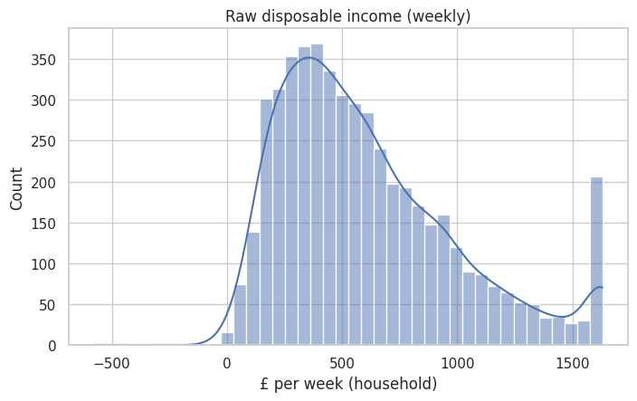

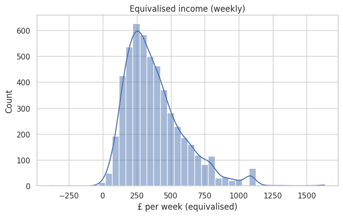

```
Saved histograms to /content/drive/MyDrive/UBI_Project/figures/section3
```

```python
# ---- Section 3: Equivalise income + quick stats + plots (Steps 1–3) ----
import numpy as np
import pandas as pd
import matplotlib.pyplot as plt
import seaborn as sns
from pathlib import Path

# Work on a reference to your merged table
df = merged.copy()

# 1) Equivalise disposable income (baseline)
# Prefer a standardised 'eq_scale' if you already renamed; else try raw 'OECDSc'; else fallback from n_adult/n_child
if "eq_scale" in df.columns:
    df["eq_hh_size"] = pd.to_numeric(df["eq_scale"], errors="coerce")
elif "OECDSc" in df.columns:
    df["eq_hh_size"] = pd.to_numeric(df["OECDSc"], errors="coerce")
else:
    a = pd.to_numeric(df.get("n_adult"), errors="coerce")
    c = pd.to_numeric(df.get("n_child"), errors="coerce")
    df["eq_hh_size"] = 1.0 + np.maximum((a - 1), 0) * 0.5 + (c.fillna(0) * 0.3)

# Income to numeric
df["disp_income_week"] = pd.to_numeric(df["disp_income_week"], errors="coerce")

# Equivalised income (baseline)
df["eq_pre"] = df["disp_income_week"] / df["eq_hh_size"]

# 2) Quick stats to guide winsorise/log decisions
def p_ratio(series, p_hi=0.99, p_mid=0.50):
    s = pd.to_numeric(series, errors="coerce")
    q_hi = s.quantile(p_hi)
    q_md = s.quantile(p_mid)
    return (q_hi / q_md) if (q_md and q_md != 0) else np.nan

stats = {
    "raw_median":      float(df["disp_income_week"].median(skipna=True)),
    "raw_skew":        float(df["disp_income_week"].skew(skipna=True)),
    "raw_P99/P50":     float(p_ratio(df["disp_income_week"], 0.99, 0.50)),
    "eq_median":       float(df["eq_pre"].median(skipna=True)),
    "eq_skew":         float(df["eq_pre"].skew(skipna=True)),
    "eq_P99/P50":      float(p_ratio(df["eq_pre"], 0.99, 0.50)),
    "n_missing_eq_pre": int(df["eq_pre"].isna().sum()),
}
print("=== Summary (use this to decide on winsorise/log) ===")
for k, v in stats.items():
    print(f"{k:>16}: {v}")

# 3) Plots: raw vs equivalised
def hist1(series, title, xlabel, bins=40):
    s = pd.to_numeric(series, errors="coerce").dropna()
    plt.figure(figsize=(7.2,4.6))
    sns.histplot(s, bins=bins, kde=True)
    plt.title(title)
    plt.xlabel(xlabel); plt.ylabel("Count"); plt.tight_layout()
    plt.show()

hist1(df["disp_income_week"], "Raw disposable income (weekly)", "£ per week (household)")
hist1(df["eq_pre"],           "Equivalised income (weekly)",    "£ per week (equivalised)")

# Optional: save figures if your FIG_DIR exists in CONFIG
try:
    fig_dir = Path(CONFIG["FIG_DIR"]) / "section3"
    fig_dir.mkdir(parents=True, exist_ok=True)
    # Re-plot and save
    for ser, ttl, fname in [
        (df["disp_income_week"], "Raw disposable income (weekly)", "hist_raw_disp_income.png"),
        (df["eq_pre"],           "Equivalised income (weekly)",    "hist_eq_pre.png"),
    ]:
        s = pd.to_numeric(ser, errors="coerce").dropna()
        plt.figure(figsize=(7.2,4.6))
        sns.histplot(s, bins=40, kde=True)
        plt.title(ttl); plt.xlabel("£ per week"); plt.ylabel("Count"); plt.tight_layout()
        plt.savefig(fig_dir / fname, dpi=150)
        plt.close()
    print(f"Saved histograms to {fig_dir}")
except Exception as e:
    print(f"[note] Skipped saving figures: {e}")

# Keep df with new columns available for the next steps
merged_eq = df  # use merged_eq going forward, or overwrite `merged = df` if you prefer
```

```python
import numpy as np
import pandas as pd
from scipy.stats.mstats import winsorize

# --- Pick the right dataframe variable here ---
df = merged   # <-- if your df is called merged_df, change this line to: df = merged_df

# Quick sanity check
print("Has eq_income_week?", "eq_income_week" in df.columns)
print("Columns example:", list(df.columns)[:10])

# (Re)compute equivalised income if needed
if "eq_income_week" not in df.columns:
    if {"disp_income_week", "hh_size"}.issubset(df.columns):
        disp = pd.to_numeric(df["disp_income_week"], errors="coerce")
        eqsz = pd.to_numeric(df["hh_size"], errors="coerce")
        df["eq_income_week"] = disp / eqsz
        print("✅ Recomputed eq_income_week from disp_income_week / hh_size.")
    else:
        raise KeyError("Missing prerequisites to build eq_income_week: need 'disp_income_week' and 'hh_size'.")

# --- Winsorise at 1st/99th percentiles (both tails) ---
s = pd.to_numeric(df["eq_income_week"], errors="coerce")
w = winsorize(s.to_numpy(), limits=(0.01, 0.01))       # returns a masked array
w = np.asarray(w, dtype=float)                         # plain numpy array

df["eq_income_week_winz"] = pd.Series(w, index=df.index)

# --- Log transform (clip negatives to 0 to avoid log of <= 0) ---
df["log_eq_income"] = np.log1p(np.clip(df["eq_income_week_winz"], 0, None))

print("✅ Added columns: 'eq_income_week_winz', 'log_eq_income'")
print(df[["eq_income_week","eq_income_week_winz","log_eq_income"]].head())
```

```
Has eq_income_week? False
Columns example: ['case', 'hh_size', 'n_adult', 'n_child', 'age', 'sex_code', 'emp_code', 'eth_code', 'mar_code', 'tenure_code']
✅ Recomputed eq_income_week from disp_income_week / hh_size.
✅ Added columns: 'eq_income_week_winz', 'log_eq_income'
   eq_income_week  eq_income_week_winz  log_eq_income
0        203.5725             203.5725       5.320922
1        176.7050             176.7050       5.180125
2        135.9500             135.9500       4.919616
3        331.7100             331.7100       5.807271
4        146.1400             146.1400       4.991385
```

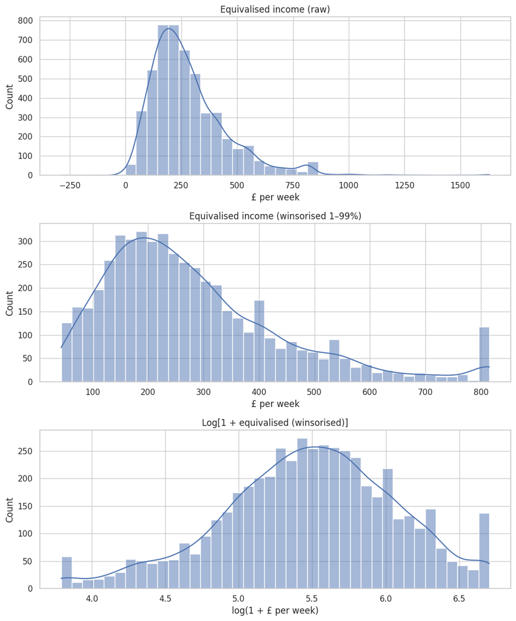

```python
import matplotlib.pyplot as plt
import seaborn as sns
import pandas as pd

df = merged  # change if needed

cols = [
    ("eq_income_week",       "Equivalised income (raw)"),
    ("eq_income_week_winz",  "Equivalised income (winsorised 1–99%)"),
    ("log_eq_income",        "Log[1 + equivalised (winsorised)]"),
]

plt.figure(figsize=(10, 12))
for i, (c, title) in enumerate(cols, start=1):
    if c not in df.columns:
        print(f"[skip] {c} not in dataframe")
        continue
    s = pd.to_numeric(df[c], errors="coerce").dropna()
    ax = plt.subplot(3, 1, i)
    sns.histplot(s, bins=40, kde=True)
    ax.set_title(title)
    ax.set_xlabel("£ per week" if "log" not in c else "log(1 + £ per week)")
    ax.set_ylabel("Count")
plt.tight_layout()
plt.show()
```

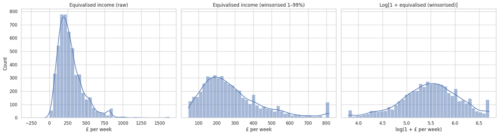

```python
import matplotlib.pyplot as plt
import seaborn as sns
import pandas as pd

# Make sure df = merged
df = merged

# Columns: (col_name, pretty_title)
cols = [
    ("eq_income_week", "Equivalised income (raw)"),
    ("eq_income_week_winz", "Equivalised income (winsorised 1–99%)"),
    ("log_eq_income", "Log[1 + equivalised (winsorised)]")
]

# Create figure with 1 row, 3 columns
fig, axes = plt.subplots(1, 3, figsize=(18, 5), sharey=True)

# Loop through and plot
for ax, (c, title) in zip(axes, cols):
    if c not in df.columns:
        print(f"[skip] {c} not in dataframe")
        continue
    s = pd.to_numeric(df[c], errors="coerce").dropna()
    sns.histplot(s, bins=40, kde=True, ax=ax)
    ax.set_title(title)
    ax.set_xlabel("£ per week" if "log" not in c else "log(1 + £ per week)")
    ax.set_ylabel("Count")

plt.tight_layout()

# Save to Google Drive
plt.savefig("/content/drive/MyDrive/UBI_Project/figures/section3/eq_income_hists_side_by_side.png", dpi=300)

plt.show()
```

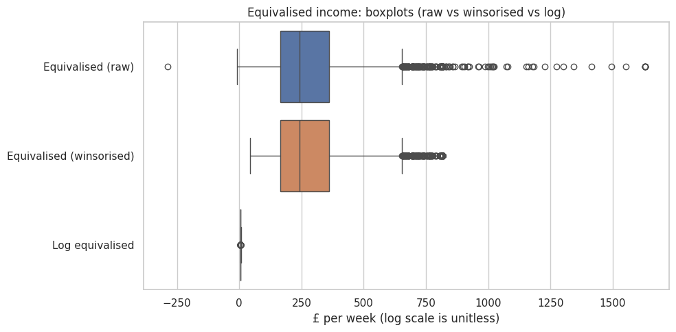

```python
import matplotlib.pyplot as plt
import seaborn as sns
import pandas as pd

df = merged

plot_df = pd.DataFrame({
    "Equivalised (raw)":       pd.to_numeric(df.get("eq_income_week"), errors="coerce"),
    "Equivalised (winsorised)":pd.to_numeric(df.get("eq_income_week_winz"), errors="coerce"),
    "Log equivalised":         pd.to_numeric(df.get("log_eq_income"), errors="coerce"),
})

plt.figure(figsize=(10, 5))
sns.boxplot(data=plot_df, orient="h")
plt.title("Equivalised income: boxplots (raw vs winsorised vs log)")
plt.xlabel("£ per week (log scale is unitless)")
plt.tight_layout()
plt.savefig("/content/drive/MyDrive/UBI_Project/figures/section3/eq_income_boxplot.png", dpi=300)
plt.show()
```

```python
import numpy as np
import pandas as pd
from pathlib import Path

df = merged  # change if needed

def p_ratio(series, p_hi=0.99, p_mid=0.50):
    s = pd.to_numeric(series, errors="coerce").dropna()
    q_hi = s.quantile(p_hi)
    q_md = s.quantile(p_mid)
    return float(q_hi / q_md) if (q_md and q_md != 0) else np.nan

def stats_for(name, series):
    s = pd.to_numeric(series, errors="coerce").dropna()
    return {
        "count":     int(s.size),
        "missing":   int(series.isna().sum()),
        "min":       float(np.nanmin(s)) if s.size else np.nan,
        "p25":       float(np.nanpercentile(s, 25)) if s.size else np.nan,
        "p50":       float(np.nanmedian(s)) if s.size else np.nan,
        "p75":       float(np.nanpercentile(s, 75)) if s.size else np.nan,
        "p99":       float(np.nanpercentile(s, 99)) if s.size else np.nan,
        "max":       float(np.nanmax(s)) if s.size else np.nan,
        "skew":      float(s.skew()) if s.size else np.nan,
        "P99/P50":   p_ratio(series, 0.99, 0.50),
        "negatives": int((s < 0).sum()) if s.size else 0,
        "zeros":     int((s == 0).sum()) if s.size else 0,
    }

summary = pd.DataFrame.from_dict({
    "eq_income_week (raw)":        stats_for("raw",        df["eq_income_week"]),
    "eq_income_week_winz (1–99%)": stats_for("winsorised", df["eq_income_week_winz"]),
    "log_eq_income":               stats_for("log",        df["log_eq_income"]),
}, orient="index")

display(summary)

# Save table to your project folder if CONFIG is set; else save locally.
try:
    out_dir = Path(CONFIG["DATA_DIR"]) / "tables" / "section3"
except Exception:
    out_dir = Path("./")
out_dir.mkdir(parents=True, exist_ok=True)
out_path = out_dir / "equivalised_income_summary.csv"
summary.to_csv(out_path)
print(f"Saved summary to: {out_path}")
```

|  | count | missing | min | p25 | p50 | p75 | p99 | max | skew | P99/P50 | negatives | zeros |
| --- | --- | --- | --- | --- | --- | --- | --- | --- | --- | --- | --- | --- |
| eq_income_week (raw) | 5133 | 0 | -288.624000 | 163.76000 | 243.275000 | 360.000000 | 815.280000 | 1630.560000 | 1.877557 | 3.351269 | 2 | 7 |
| eq_income_week_winz (1–99%) | 5133 | 0 | 43.350000 | 163.76000 | 243.275000 | 360.000000 | 815.280000 | 815.280000 | 1.211855 | 3.351269 | 0 | 0 |
| log_eq_income | 5133 | 0 | 3.792113 | 5.10449 | 5.498295 | 5.888878 | 6.704757 | 6.704757 | -0.317657 | 1.219425 | 0 | 0 |

```
Saved summary to: /content/drive/MyDrive/UBI_Project/data/tables/section3/equivalised_income_summary.csv
```

```python
import pandas as pd
import numpy as np

df = merged  # <- your merged dataframe

# Nice missingness table (count + %)
miss_tbl = (
    df.isna()
      .sum()
      .to_frame("n_missing")
      .assign(pct_missing=lambda t: (t["n_missing"]/len(df)).round(4))
      .sort_values("pct_missing", ascending=False)
)

display(miss_tbl.head(30))
miss_tbl.to_csv(TAB_DIR / "/content/drive/MyDrive/UBI_Project/data/tables/section3"/ "missingness_overview.csv")
print("Saved: missingness_overview.csv")
```

|  | n_missing | pct_missing |
| --- | --- | --- |
| educ_cat | 1522 | 0.2965 |
| educ_code | 1522 | 0.2965 |
| n_adult | 0 | 0.0000 |
| n_child | 0 | 0.0000 |
| age | 0 | 0.0000 |
| sex_code | 0 | 0.0000 |
| emp_code | 0 | 0.0000 |
| eth_code | 0 | 0.0000 |
| case | 0 | 0.0000 |
| hh_size | 0 | 0.0000 |
| tenure_code | 0 | 0.0000 |
| mar_code | 0 | 0.0000 |
| lone_parent | 0 | 0.0000 |
| region_code | 0 | 0.0000 |
| eq_scale | 0 | 0.0000 |
| sex_cat | 0 | 0.0000 |
| emp_cat | 0 | 0.0000 |
| disp_income_week | 0 | 0.0000 |
| eth_cat | 0 | 0.0000 |
| mar_cat | 0 | 0.0000 |
| tenure_cat | 0 | 0.0000 |
| region_cat | 0 | 0.0000 |
| lone_parent_cat | 0 | 0.0000 |
| eq_income_week | 0 | 0.0000 |
| eq_income_week_winz | 0 | 0.0000 |
| log_eq_income | 0 | 0.0000 |

```
Saved: missingness_overview.csv
```

```python
df = merged.copy()

NUM_IMPUTE = ["age"]  # add others if any numeric demo features appear later
CAT_IMPUTE = ["sex_code","emp_code","eth_code","mar_code",
              "tenure_code","region_code","educ_code","lone_parent"]

# Numeric -> median
for c in NUM_IMPUTE:
    mlc = f"{c}_ml"
    df[mlc] = pd.to_numeric(df[c], errors="coerce")
    med = df[mlc].median()
    df[mlc] = df[mlc].fillna(med)
    df[f"{c}_was_missing"] = df[c].isna().astype(int)

# Categorical -> mode (most frequent code)
for c in CAT_IMPUTE:
    mlc = f"{c}_ml"
    df[mlc] = pd.to_numeric(df[c], errors="coerce")
    mode_val = df[mlc].mode(dropna=True)
    mode_val = mode_val.iloc[0] if len(mode_val) else 0  # safe fallback
    df[f"{c}_was_missing"] = df[mlc].isna().astype(int)
    df[mlc] = df[mlc].fillna(mode_val)

# Income columns: keep as-is for analysis; for ML we can carry winsorised/log
df["eq_income_week_ml"]      = pd.to_numeric(df["eq_income_week"], errors="coerce")
df["eq_income_week_winz_ml"] = pd.to_numeric(df["eq_income_week_winz"], errors="coerce")
df["log_eq_income_ml"]       = pd.to_numeric(df["log_eq_income"], errors="coerce")

# Quick check that ML set has no NAs in the columns we’ll model with
ml_cols = ["age_ml","sex_code_ml","emp_code_ml","eth_code_ml","mar_code_ml",
           "tenure_code_ml","region_code_ml","educ_code_ml","lone_parent_ml",
           "eq_income_week_winz_ml","log_eq_income_ml"]
print("Any NA in ML columns? ->", df[ml_cols].isna().any().any())
```

```
Any NA in ML columns? -> False
```

```python
# a) Descriptive/analysis set (no imputation)
report_cols = [
    "case","hh_size","n_adult","n_child","age",
    "sex_code","emp_code","eth_code","mar_code","tenure_code","region_code","educ_code","lone_parent",
    "disp_income_week","eq_scale","eq_income_week","eq_income_week_winz","log_eq_income"
]
report_cols = [c for c in report_cols if c in df.columns]
display(df[report_cols].head(12))

df[report_cols].head(50).to_csv(TAB_DIR / "/content/drive/MyDrive/UBI_Project/data/tables/section3" / "merged_preview_for_report.csv", index=False)
print("Saved: merged_preview_for_report.csv")

# b) ML-ready set preview
ml_preview = [c for c in ml_cols if c in df.columns] + [c for c in df.columns if c.endswith("_was_missing")]
display(df[ml_preview].head(12))
df[ml_preview].to_csv(TAB_DIR / "ml_ready.csv", index=False)   # full
df[ml_preview].head(50).to_csv(TAB_DIR / "ml_ready_preview.csv", index=False)  # preview only
print("Saved: ml_ready_preview.csv")
```

|  | case | hh_size | n_adult | n_child | age | sex_code | emp_code | eth_code | mar_code | tenure_code | region_code | educ_code | lone_parent | disp_income_week | eq_scale | eq_income_week | eq_income_week_winz | log_eq_income |
| --- | --- | --- | --- | --- | --- | --- | --- | --- | --- | --- | --- | --- | --- | --- | --- | --- | --- | --- |
| 0 | 1 | 4.0 | 2.0 | 2.0 | 34.0 | 2.0 | 2.0 | 1.0 | 1.0 | 5.0 | 5.0 | 1.0 | 2.0 | 814.2900 | 2.1 | 203.5725 | 203.5725 | 5.320922 |
| 1 | 2 | 4.0 | 2.0 | 2.0 | 38.0 | 1.0 | 2.0 | 1.0 | 1.0 | 5.0 | 1.0 | 1.0 | 2.0 | 706.8200 | 2.1 | 176.7050 | 176.7050 | 5.180125 |
| 2 | 3 | 2.0 | 2.0 | 0.0 | 54.0 | 1.0 | 7.0 | 1.0 | 6.0 | 3.0 | 12.0 | 8.0 | 2.0 | 271.9000 | 1.5 | 135.9500 | 135.9500 | 4.919616 |
| 3 | 4 | 2.0 | 2.0 | 0.0 | 64.0 | 1.0 | 1.0 | 1.0 | 1.0 | 5.0 | 2.0 | 5.0 | 2.0 | 663.4200 | 1.5 | 331.7100 | 331.7100 | 5.807271 |
| 4 | 5 | 3.0 | 3.0 | 0.0 | 64.0 | 1.0 | 7.0 | 1.0 | 1.0 | 7.0 | 4.0 | 2.0 | 2.0 | 438.4200 | 2.0 | 146.1400 | 146.1400 | 4.991385 |
| 5 | 6 | 4.0 | 3.0 | 1.0 | 70.0 | 1.0 | 1.0 | 1.0 | 1.0 | 7.0 | 10.0 | NaN | 2.0 | 266.5300 | 2.3 | 66.6325 | 66.6325 | 4.214089 |
| 6 | 7 | 1.0 | 1.0 | 0.0 | 53.0 | 2.0 | 2.0 | 1.0 | 4.0 | 7.0 | 7.0 | 5.0 | 2.0 | 606.7806 | 1.0 | 606.7806 | 606.7806 | 6.409814 |
| 7 | 8 | 3.0 | 3.0 | 0.0 | 64.0 | 1.0 | 7.0 | 1.0 | 1.0 | 7.0 | 6.0 | NaN | 2.0 | 399.9000 | 2.0 | 133.3000 | 133.3000 | 4.900076 |
| 8 | 9 | 1.0 | 1.0 | 0.0 | 79.0 | 1.0 | 6.0 | 1.0 | 8.0 | 1.0 | 7.0 | NaN | 2.0 | 88.1420 | 1.0 | 88.1420 | 88.1420 | 4.490231 |
| 9 | 10 | 2.0 | 2.0 | 0.0 | 72.0 | 1.0 | 1.0 | 1.0 | 1.0 | 5.0 | 2.0 | NaN | 2.0 | 935.5800 | 1.5 | 467.7900 | 467.7900 | 6.150155 |
| 10 | 11 | 1.0 | 1.0 | 0.0 | 57.0 | 1.0 | 7.0 | 1.0 | 6.0 | 2.0 | 2.0 | NaN | 2.0 | 108.0500 | 1.0 | 108.0500 | 108.0500 | 4.691806 |
| 11 | 12 | 3.0 | 3.0 | 0.0 | 56.0 | 1.0 | 1.0 | 1.0 | 1.0 | 7.0 | 2.0 | 1.0 | 2.0 | 1630.5600 | 2.0 | 543.5200 | 543.5200 | 6.299905 |

```
Saved: merged_preview_for_report.csv
```

|  | age_ml | sex_code_ml | emp_code_ml | eth_code_ml | mar_code_ml | tenure_code_ml | region_code_ml | educ_code_ml | lone_parent_ml | eq_income_week_winz_ml | log_eq_income_ml | age_was_missing | sex_code_was_missing | emp_code_was_missing | eth_code_was_missing | mar_code_was_missing | tenure_code_was_missing | region_code_was_missing | educ_code_was_missing | lone_parent_was_missing |
| --- | --- | --- | --- | --- | --- | --- | --- | --- | --- | --- | --- | --- | --- | --- | --- | --- | --- | --- | --- | --- |
| 0 | 34.0 | 2.0 | 2.0 | 1.0 | 1.0 | 5.0 | 5.0 | 1.0 | 2.0 | 203.5725 | 5.320922 | 0 | 0 | 0 | 0 | 0 | 0 | 0 | 0 | 0 |
| 1 | 38.0 | 1.0 | 2.0 | 1.0 | 1.0 | 5.0 | 1.0 | 1.0 | 2.0 | 176.7050 | 5.180125 | 0 | 0 | 0 | 0 | 0 | 0 | 0 | 0 | 0 |
| 2 | 54.0 | 1.0 | 7.0 | 1.0 | 6.0 | 3.0 | 12.0 | 8.0 | 2.0 | 135.9500 | 4.919616 | 0 | 0 | 0 | 0 | 0 | 0 | 0 | 0 | 0 |
| 3 | 64.0 | 1.0 | 1.0 | 1.0 | 1.0 | 5.0 | 2.0 | 5.0 | 2.0 | 331.7100 | 5.807271 | 0 | 0 | 0 | 0 | 0 | 0 | 0 | 0 | 0 |
| 4 | 64.0 | 1.0 | 7.0 | 1.0 | 1.0 | 7.0 | 4.0 | 2.0 | 2.0 | 146.1400 | 4.991385 | 0 | 0 | 0 | 0 | 0 | 0 | 0 | 0 | 0 |
| 5 | 70.0 | 1.0 | 1.0 | 1.0 | 1.0 | 7.0 | 10.0 | 1.0 | 2.0 | 66.6325 | 4.214089 | 0 | 0 | 0 | 0 | 0 | 0 | 0 | 1 | 0 |
| 6 | 53.0 | 2.0 | 2.0 | 1.0 | 4.0 | 7.0 | 7.0 | 5.0 | 2.0 | 606.7806 | 6.409814 | 0 | 0 | 0 | 0 | 0 | 0 | 0 | 0 | 0 |
| 7 | 64.0 | 1.0 | 7.0 | 1.0 | 1.0 | 7.0 | 6.0 | 1.0 | 2.0 | 133.3000 | 4.900076 | 0 | 0 | 0 | 0 | 0 | 0 | 0 | 1 | 0 |
| 8 | 79.0 | 1.0 | 6.0 | 1.0 | 8.0 | 1.0 | 7.0 | 1.0 | 2.0 | 88.1420 | 4.490231 | 0 | 0 | 0 | 0 | 0 | 0 | 0 | 1 | 0 |
| 9 | 72.0 | 1.0 | 1.0 | 1.0 | 1.0 | 5.0 | 2.0 | 1.0 | 2.0 | 467.7900 | 6.150155 | 0 | 0 | 0 | 0 | 0 | 0 | 0 | 1 | 0 |
| 10 | 57.0 | 1.0 | 7.0 | 1.0 | 6.0 | 2.0 | 2.0 | 1.0 | 2.0 | 108.0500 | 4.691806 | 0 | 0 | 0 | 0 | 0 | 0 | 0 | 1 | 0 |
| 11 | 56.0 | 1.0 | 1.0 | 1.0 | 1.0 | 7.0 | 2.0 | 1.0 | 2.0 | 543.5200 | 6.299905 | 0 | 0 | 0 | 0 | 0 | 0 | 0 | 0 | 0 |

```
Saved: ml_ready_preview.csv
```

```python
# Confirm saved file shapes
print("Full ML-ready dataset shape:", df[ml_preview].shape)
print("Preview (50 rows) shape:", df[ml_preview].head(50).shape)
```

```
Full ML-ready dataset shape: (5133, 20)
Preview (50 rows) shape: (50, 20)
```

```python
# SAVE FULL + PREVIEW (use df and ml_preview)
from pathlib import Path
from os import stat

ROOT = Path("/content/drive/MyDrive/UBI_Project")
TAB_DIR = ROOT / "data" / "tables" / "section3"
TAB_DIR.mkdir(parents=True, exist_ok=True)

print("About to save. Full ML-ready shape:", df[ml_preview].shape)

# FULL dataset for modelling
(df[ml_preview]).to_csv(TAB_DIR / "ml_ready.csv", index=False)

# 50-row PREVIEW for eyeballing only
(df[ml_preview].head(50)).to_csv(TAB_DIR / "ml_ready_preview.csv", index=False)

# sanity: show file sizes
print("FULL bytes:",  stat(str(TAB_DIR / "ml_ready.csv")).st_size)
print("PREVIEW bytes:", stat(str(TAB_DIR / "ml_ready_preview.csv")).st_size)
```

```
About to save. Full ML-ready shape: (5133, 20)
FULL bytes: 422731
PREVIEW bytes: 4484
```

```python
import pandas as pd

# Select demographic variables (adjust this list to match your merged df)

demo_vars = [
    "age",            # numeric
    "sex_cat",        # categorical
    "region_cat",     # categorical
    "emp_cat",        # employment status
    "educ_cat",       # education level
    "hh_size",        # household size
    "eth_cat",
    "mar_cat",
    "tenure_cat"
]


# Summary function
def describe_demographics(df, cols):
    summaries = {}
    for col in cols:
        if df[col].dtype == "object" or df[col].dtype.name == "category":
            counts = df[col].value_counts(dropna=False)
            perc = df[col].value_counts(normalize=True, dropna=False) * 100
            summary = pd.DataFrame({"count": counts, "percent": perc.round(1)})
        else:
            summary = df[col].describe(percentiles=[.25, .5, .75]).to_frame(name=col)
        summaries[col] = summary
    return summaries

# Run
demo_summaries = describe_demographics(merged, demo_vars)

# Print each nicely
for col, summary in demo_summaries.items():
    print(f"\n--- {col} ---")
    print(summary)
```

```
--- age ---
               age
count  5133.000000
mean     53.831872
std      16.196137
min      17.000000
25%      41.000000
50%      54.000000
75%      67.000000
max      80.000000

--- sex_cat ---
         count  percent
sex_cat
Male      3058     59.6
Female    2075     40.4

--- region_cat ---
                           count  percent
region_cat
South East                   740     14.4
North West and Merseyside    588     11.5
Eastern                      498      9.7
West Midlands                470      9.2
South West                   468      9.1
Yorkshire and the Humber     459      8.9
East Midlands                440      8.6
Scotland                     434      8.5
London                       407      7.9
North East                   255      5.0
Wales                        222      4.3
Northern Ireland             152      3.0

--- emp_cat ---
                                                    count  percent
emp_cat
Full-time employee                                   2017     39.3
Retired/unoccupied and of minimum NI Pension age     1455     28.3
Part-time employee                                    574     11.2
Retired/unoccupied but under minimum NI Pension...    549     10.7
```

[output cut: 44 more lines]

```
Divorced                                     499      9.7
Separated                                    191      3.7
Civil Partner or Former Civil Partner         26      0.5

--- tenure_cat ---
                                count  percent
tenure_cat
Owned outright                   1906     37.1
Owned with mortgage              1575     30.7
Priv. rented (unfurn)             607     11.8
LA (furnished unfurnished)        455      8.9
Hsng Assn (furnished unfrnish)    407      7.9
Priv. rented (furnished)          112      2.2
Rent free                          53      1.0
Owned by rental purchase           18      0.4
```